```r
#quitar los numerales para instalar las librerias

#instalacion de librerias
#install.packages('tidyverse')
#install.packages('readxl')
#install.packages('FactoMineR')
#install.packages('factoextra')
#install.packages('cluster')
#install.packages('NbClust')
#install.packages('gridExtra')
#install.packages('corrplot')
#install.packages('plotly')
#install.packages('DT')
#install.packages('pheatmap')
#install.packages('fmsb')
#install.packages('visdat')
#install.packages("ggdendro")
#install.packages("Hmisc")
#install.packages("e1071")
#install.packages("kableExtra")
```

```r
# Librerías necesarias
library(tidyverse)
library(readxl)
library(FactoMineR)
library(factoextra)
library(cluster)
library(NbClust)
library(gridExtra)
library(corrplot)
library(plotly)
library(DT)
library(pheatmap)
library(fmsb)
library(visdat)
```

# 1. LIMPIEZA Y TRANSFORMACION DE LOS DATOS

```r
#chunk1.1
# Cargar datos
datos_raw <- read_excel("datos/Encuesta_limpia.xlsx")

# Asignar nombres cortos
nombres_cortos <- c(
  "empresa", "tipo_estructura", "depto", "ubicacion_extra", "area_acceso",
  "direccion", "tiempo_actividad", "n_empleados", "lineas_comerciales", "especializacion",
  "usa_credito", "facil_credito", "valor_cupo", "tiene_presupuesto", "compra_mensual",
  "prob_recompra", "calidad_vs_precio", "frec_compra", "satis_frecuencia", "frec_urgencias",
  "infl_descuentos", "recomendaria", "marca_memorable", "marca_memorable_cual", "prod_fidelidad",
  "prod_fidelidad_cual", "publicidad", "asistencia_tecnica", "n_clientes", "valor_distribuidor",
  "cond_permanencia", "encuentra_productos", "tiene_alternativas", "tiempo_proveedor",
  "prod_estrella1", "precio_prod1", "prod_estrella2", "precio_prod2", "prod_estrella3", "precio_prod3",
  "prod_estrella4", "precio_prod4", "prod_estrella5", "precio_prod5", "vehiculo_propio",
  "entregas_mes", "ventas_mes", "almacenamiento", "medida_almacen", "tiempo_espera", "tipo_punto_venta"
)

if (ncol(datos_raw) == length(nombres_cortos)) {
  colnames(datos_raw) <- nombres_cortos
} else {
  colnames(datos_raw) <- nombres_cortos[1:ncol(datos_raw)]
}

# Verificar estructura inicial
glimpse(datos_raw)
```

```
## Rows: 99
## Columns: 51
## $ empresa              <chr> "Almacenes Federación Nacional De Cafeteros", "It…
## $ tipo_estructura      <chr> "Almacén", "Unipersonal", "Unipersonal", "Socieda…
## $ depto                <chr> "Quindio", "Quindio", "Quindio", "Quindio", "Quin…
## $ ubicacion_extra      <chr> "Cabecera municipal", "Cabecera municipal", "Cabe…
## $ area_acceso          <chr> "Urbano", "Urbano", "Urbano", "Urbano", "Urbano",…
## $ direccion            <chr> "Cra 7 #  15 06", "Cra 6 # 18 13", "Cra 7 # 20-24…
## $ tiempo_actividad     <chr> "10 años en adelante", "10 años en adelante", "10…
## $ n_empleados          <dbl> 3, 4, 3, 1, 5, 8, 10, 4, 1, 5, 1, 1, 3, 2, 2, 3, …
## $ lineas_comerciales   <chr> "Agrícolas", "Equino, Porcicultura, Mascotas", "M…
## $ especializacion      <chr> "Agrícolas", "Porcicultura", "Mascotas", "Porcicu…
## $ usa_credito          <chr> "Si, frecuentemente", "Si, frecuentemente", "No, …
## $ facil_credito        <dbl> 4, 2, 5, 1, 3, 1, 5, 4, 3, 3, 2, 5, 4, 4, 3, 5, 5…
## $ valor_cupo           <chr> "mayor a  $10'000.000", "mayor a  $10'000.000", "…
```

[output cut: 38 more lines]

```r
cat("Número de variables disponibles antes de iniciar el AED:", ncol(datos_raw), "\n\n")
```

```
## Número de variables disponibles antes de iniciar el AED: 51
```

```r
vars <- names(datos_raw)
data.frame(
  Variables1 = vars[1:17],
  Variables2 = vars[18:34],
  Variables3 = vars[35:51]
)
```

```
##            Variables1           Variables2       Variables3
## 1             empresa          frec_compra   prod_estrella1
## 2     tipo_estructura     satis_frecuencia     precio_prod1
## 3               depto       frec_urgencias   prod_estrella2
## 4     ubicacion_extra      infl_descuentos     precio_prod2
## 5         area_acceso         recomendaria   prod_estrella3
## 6           direccion      marca_memorable     precio_prod3
## 7    tiempo_actividad marca_memorable_cual   prod_estrella4
## 8         n_empleados       prod_fidelidad     precio_prod4
## 9  lineas_comerciales  prod_fidelidad_cual   prod_estrella5
## 10    especializacion           publicidad     precio_prod5
## 11        usa_credito   asistencia_tecnica  vehiculo_propio
## 12      facil_credito           n_clientes     entregas_mes
## 13         valor_cupo   valor_distribuidor       ventas_mes
## 14  tiene_presupuesto     cond_permanencia   almacenamiento
## 15     compra_mensual  encuentra_productos   medida_almacen
## 16      prob_recompra   tiene_alternativas    tiempo_espera
## 17  calidad_vs_precio     tiempo_proveedor tipo_punto_venta
```

Eliminar variables no relevantes

```r
#chunk 1.2
# Variables que no aportan al clustering (texto libre, IDs, nombres)
variables_eliminar <- c(
  "empresa", "direccion", "marca_memorable_cual", "prod_fidelidad_cual",
  "prod_estrella1", "prod_estrella2", "prod_estrella3", "prod_estrella4", "prod_estrella5",
  "precio_prod1", "precio_prod2", "precio_prod3", "precio_prod4", "precio_prod5"
)

datos_limpios <- datos_raw %>%
  select(-any_of(variables_eliminar))
```

Transformacion de variables

```r
#chunk1.3
datos_limpios <- datos_limpios %>%
  mutate(
    # Tiempo en actividad
    tiempo_actividad_num = case_when(
      tiempo_actividad == "De 1 a 5 años" ~ 1,
      tiempo_actividad == "de 5 a 10 años" ~ 2,
      tiempo_actividad == "10 años en adelante" ~ 3,
      TRUE ~ NA_real_
    ),

    # Cupo de crédito
    valor_cupo_num = case_when(
      valor_cupo == "Menor a $1'000.000" ~ 1,
      valor_cupo == "Entre $1'000.000 y $5'000.000" ~ 2,
      valor_cupo == "Entre $5'000.000 y $10'000.000" ~ 3,
      valor_cupo == "mayor a  $10'000.000" ~ 4,
      TRUE ~ NA_real_
    ),

    # Compra mensual
    compra_mensual_num = case_when(
      compra_mensual == "menos de $500.000" ~ 1,
      compra_mensual == "entre $500.000 y $1'000.000" ~ 2,
      compra_mensual == "entre $1'000.000 y $5'000.000" ~ 3,
      compra_mensual == "entre $5'000.000 y $10'000.000" ~ 4,
      compra_mensual == "más de $10'000.000" ~ 5,
      TRUE ~ NA_real_
    ),

    # Calidad vs Precio (Likert 1-5)
    calidad_vs_precio_num = case_when(
      calidad_vs_precio == "Priorizo totalmente el precio, incluso si la calidad es inferior." ~ 1,
      calidad_vs_precio == "Le doy más importancia al precio que a la calidad." ~ 2,
      calidad_vs_precio == "Ambos factores son igual de importantes." ~ 3,
      calidad_vs_precio == "Le doy más importancia a la calidad que al precio." ~ 4,
      calidad_vs_precio == "Priorizo totalmente la calidad, incluso si el precio es más alto." ~ 5,
      TRUE ~ NA_real_
    ),

    # Frecuencia de compra
    frec_compra_num = case_when(
      frec_compra == "Semanal" ~ 1,
      frec_compra == "Quincenal" ~ 2,
      frec_compra == "Mensual" ~ 3,
      frec_compra == "Trimestral" ~ 4,
      TRUE ~ 5
    ),

    # Frecuencia de urgencias
    frec_urgencias_num = case_when(
      frec_urgencias == "Siempre" ~ 1,
      frec_urgencias == "Frecuentemente" ~ 2,
      frec_urgencias == "Ocasionalmente" ~ 3,
      frec_urgencias == "Muy rara vez" ~ 4,
      frec_urgencias == "Nunca" ~ 5,
      TRUE ~ NA_real_
    ),

    # Tiempo de espera
    tiempo_espera_num = case_when(
      tiempo_espera == "1-2 días" ~ 1,
      tiempo_espera == "2-5 días" ~ 2,
      tiempo_espera == "5-10 días" ~ 3,
      TRUE ~ NA_real_
    ),

    # Variables binarias (Sí/No a 1/0)
    almacenamiento_num = ifelse(almacenamiento == "Sí", 1, 0),
    tiene_alternativas_num = ifelse(tiene_alternativas == "Sí", 1, 0),
    tiene_presupuesto_num = ifelse(tiene_presupuesto == "Sí", 1, 0),
    prod_fidelidad_num = ifelse(prod_fidelidad == "Sí", 1, 0),
    marca_memorable_num = ifelse(marca_memorable == "Si", 1, 0),
    asistencia_tecnica_num = ifelse(asistencia_tecnica == "Si", 1, 0),
    vehiculo_propio_num = ifelse(vehiculo_propio == "Sí", 1, 0),
    recomendaria_num = ifelse(recomendaria == "Sí", 1, 0),

    # Tipo de punto de venta (ordinal: físico=1, virtual=2, ambos=3)
    tipo_punto_venta_num = case_when(
      tipo_punto_venta == "Solo punto físico" ~ 1,
      tipo_punto_venta == "Solo tienda virtual" ~ 2,
      tipo_punto_venta == "Ambos" ~ 3,
      TRUE ~ NA_real_
    ),

    # Escalas numéricas directas
    facil_credito_num = as.numeric(facil_credito),
    prob_recompra_num = as.numeric(prob_recompra),
    infl_descuentos_num = as.numeric(infl_descuentos),
    encuentra_productos_num = as.numeric(encuentra_productos),
    satis_frecuencia_num = as.numeric(satis_frecuencia)
  )

#visualizacion del dataset limpio

# install.packages("kableExtra")
library(kableExtra)

datos_limpios %>%
  select(tiempo_actividad, tiempo_actividad_num,
         valor_cupo, valor_cupo_num,
         vehiculo_propio, vehiculo_propio_num,
         satis_frecuencia_num) %>%
  head(8) %>%
  kable(
    caption = "Muestra del dataset transformado (variables seleccionadas)",
    col.names = c("Tiempo actividad", "Cod.", "Valor cupo", "Cod.",
                   "Vehículo propio", "Cod.", "Satisfacción"),
    align = "c"
  ) %>%
  kable_styling(
    bootstrap_options = c("striped", "hover", "condensed"),
    full_width = FALSE,
    font_size = 12
  ) %>%
  row_spec(0, bold = TRUE, color = "white", background = "#2C3E50")
```

Muestra del dataset transformado (variables seleccionadas)

| Tiempo actividad | Cod. | Valor cupo | Cod. | Vehículo propio | Cod. | Satisfacción |
| --- | --- | --- | --- | --- | --- | --- |
| 10 años en adelante | 3 | mayor a $10’000.000 | 4 | Sí | 1 | 7 |
| 10 años en adelante | 3 | mayor a $10’000.000 | 4 | Sí | 1 | 10 |
| 10 años en adelante | 3 | mayor a $10’000.000 | 4 | No | 0 | 9 |
| De 1 a 5 años | 1 | Menor a $1’000.000 | 1 | No | 0 | 10 |
| De 1 a 5 años | 1 | mayor a $10’000.000 | 4 | No | 0 | 8 |
| 10 años en adelante | 3 | Entre $5’000.000 y $10’000.000 | 3 | Sí | 1 | 10 |
| De 1 a 5 años | 1 | Entre $5’000.000 y $10’000.000 | 3 | Sí | 1 | 10 |
| 10 años en adelante | 3 | Menor a $1’000.000 | 1 | No | 0 | 8 |

Tratamiento de variables de opcion multiple

```r
#chunk1.4
# ANÁLISIS DE OPCIONES MÚLTIPLES - PERFIL DEL SUBDISTRIBUIDOR
# ============================================


cat("ANÁLISIS DE PERFIL DE SUBDISTRIBUIDORES\n")
```

```
## ANÁLISIS DE PERFIL DE SUBDISTRIBUIDORES
```

```r
# 1. FUNCIÓN PARA CONTAR OPCIONES
# --------------------------------
contar_opciones <- function(texto, nombre_variable) {
  if (is.na(texto) | texto == "" | texto == "Ninguno" | texto == "Ninguna") {
    return(0L)  # Devolver integer explícito
  } else {
    opciones <- trimws(unlist(strsplit(as.character(texto), ",")))
    opciones_limpias <- opciones[opciones != "" & !is.na(opciones)]
    return(length(unique(opciones_limpias)))  # Esto ya es integer
  }
}

# 2. APLICAR CONTEO
# -----------------
datos_limpios <- datos_limpios %>%
  rowwise() %>%
  mutate(
    num_valores_dist = contar_opciones(valor_distribuidor, "valor_distribuidor"),
    num_cond_perm = contar_opciones(cond_permanencia, "cond_permanencia"),
    num_tipos_publicidad = contar_opciones(publicidad, "publicidad"),
    num_lineas = contar_opciones(lineas_comerciales, "lineas_comerciales")
  ) %>%
  ungroup()

# 3. VERIFICACIÓN Y LIMPIEZA DE TIPOS
# ------------------------------------
cat(" VERIFICANDO TIPOS DE DATOS...\n")
```

```
##  VERIFICANDO TIPOS DE DATOS...
```

```r
# Lista de columnas que deben ser numéricas
columnas_numericas <- c(
  # Originales numéricas
  "n_empleados", "facil_credito", "prob_recompra", "satis_frecuencia",
  "infl_descuentos", "encuentra_productos", "ventas_mes", "medida_almacen",
  "tiempo_proveedor",

  # Transformadas numéricas
  "tiempo_actividad_num", "valor_cupo_num", "compra_mensual_num",
  "calidad_vs_precio_num", "frec_compra_num", "frec_urgencias_num",
  "tiempo_espera_num", "almacenamiento_num", "tiene_alternativas_num",
  "tiene_presupuesto_num", "prod_fidelidad_num", "marca_memorable_num",
  "asistencia_tecnica_num", "vehiculo_propio_num", "recomendaria_num",
  "tipo_punto_venta_num", "facil_credito_num", "prob_recompra_num",
  "infl_descuentos_num", "encuentra_productos_num", "satis_frecuencia_num",

  # Nuevas variables de conteo
  "num_valores_dist", "num_cond_perm", "num_tipos_publicidad", "num_lineas"
)

# Filtrar solo las que existen
columnas_a_verificar <- intersect(columnas_numericas, names(datos_limpios))

for(col in columnas_a_verificar) {
  tipo_actual <- class(datos_limpios[[col]])

  # Si no es numérica, intentar convertir
  if(!is.numeric(datos_limpios[[col]])) {
    cat("   ️-", col, "es", paste(tipo_actual, collapse = "/"), "→ convirtiendo a numérico\n")

    # Intentar conversión
    nuevo_valor <- suppressWarnings(as.numeric(datos_limpios[[col]]))

    # Verificar cuántos NAs se crearon
    nas_nuevos <- sum(is.na(nuevo_valor) & !is.na(datos_limpios[[col]]))
    if(nas_nuevos > 0) {
      cat("     •", nas_nuevos, "valores se convirtieron en NA\n")
    }

    datos_limpios[[col]] <- nuevo_valor
  }
}
```

```
##    ️- tiempo_proveedor es character → convirtiendo a numérico
```

```r
# Verificar columnas character
columnas_character <- c(
  "tipo_estructura", "depto", "ubicacion_extra", "area_acceso",
  "tiempo_actividad", "lineas_comerciales", "especializacion",
  "usa_credito", "valor_cupo", "compra_mensual", "calidad_vs_precio",
  "frec_compra", "frec_urgencias", "tiempo_espera", "almacenamiento",
  "tiene_alternativas", "tiene_presupuesto", "prod_fidelidad",
  "marca_memorable", "publicidad", "asistencia_tecnica", "recomendaria",
  "vehiculo_propio", "entregas_mes", "tipo_punto_venta",
  "valor_distribuidor", "cond_permanencia"
)

columnas_character <- intersect(columnas_character, names(datos_limpios))

for(col in columnas_character) {
  if(!is.character(datos_limpios[[col]])) {
    cat("   ️-", col, "no es character → convirtiendo\n")
    datos_limpios[[col]] <- as.character(datos_limpios[[col]])
  }
}
```

```r
#chunk 1.5
# 4. ESTADÍSTICAS DESCRIPTIVAS


cat("ESTADISTICAS DESCRIPTIVAS \n")
```

ESTADISTICAS DESCRIPTIVAS

```r
# Funcion para calcular estadisticas de una variable
calcular_estadisticas <- function(x, nombre_variable) {
  tipo <- class(x)[1]
  n_total <- length(x)
  n_nulos <- sum(is.na(x))
  pct_nulos <- round(n_nulos / n_total * 100, 2)
  n_unicos <- length(unique(x[!is.na(x)]))

  resultado <- data.frame(
    Variable = nombre_variable,
    Tipo = tipo,
    N = n_total,
    Nulos = n_nulos,
    Pct_Nulos = pct_nulos,
    Unicos = n_unicos,
    stringsAsFactors = FALSE
  )

  if(is.numeric(x)) {
    x_num <- as.numeric(x)
    resultado$Media <- round(mean(x_num, na.rm = TRUE), 2)
    resultado$Mediana <- round(median(x_num, na.rm = TRUE), 2)
    resultado$Desviacion <- round(sd(x_num, na.rm = TRUE), 2)
    resultado$Minimo <- round(min(x_num, na.rm = TRUE), 2)
    resultado$Maximo <- round(max(x_num, na.rm = TRUE), 2)
    resultado$Rango <- resultado$Maximo - resultado$Minimo
    resultado$P25 <- round(quantile(x_num, 0.25, na.rm = TRUE), 2)
    resultado$P75 <- round(quantile(x_num, 0.75, na.rm = TRUE), 2)

    if(length(unique(x_num[!is.na(x_num)])) > 2) {
      resultado$Asimetria <- round(e1071::skewness(x_num, na.rm = TRUE), 3)
      resultado$Curtosis <- round(e1071::kurtosis(x_num, na.rm = TRUE), 3)
    } else {
      resultado$Asimetria <- NA
      resultado$Curtosis <- NA
    }

    resultado$Moda <- NA
    resultado$Moda_Frecuencia <- NA
    resultado$Valor_Mas_Frecuente <- NA

  } else {
    resultado$Media <- NA
    resultado$Mediana <- NA
    resultado$Desviacion <- NA
    resultado$Minimo <- NA
    resultado$Maximo <- NA
    resultado$Rango <- NA
    resultado$P25 <- NA
    resultado$P75 <- NA
    resultado$Asimetria <- NA
    resultado$Curtosis <- NA

    if(n_unicos > 0 && n_unicos <= 20) {
      freq_table <- table(x, useNA = "ifany")
      moda_valor <- names(freq_table)[which.max(freq_table)]
      moda_frec <- max(freq_table)
      resultado$Moda <- as.character(moda_valor)
      resultado$Moda_Frecuencia <- moda_frec
      resultado$Valor_Mas_Frecuente <- paste0(moda_valor, " (", moda_frec, ")")
    } else {
      resultado$Moda <- "Multiples categorias"
      resultado$Moda_Frecuencia <- n_unicos
      resultado$Valor_Mas_Frecuente <- paste(n_unicos, "categorias diferentes")
    }
  }

  return(resultado)
}

# Verificar paquete e1071
if(!require(e1071)) {
  install.packages("e1071")
  library(e1071)
}

# Calcular estadisticas
cat("Calculando estadisticas para", ncol(datos_limpios), "variables\n\n")
```

Calculando estadisticas para 62 variables

```r
lista_estadisticas <- list()
for(i in 1:ncol(datos_limpios)) {
  nombre_var <- names(datos_limpios)[i]
  cat("  Procesando:", nombre_var, "\n")
  lista_estadisticas[[i]] <- calcular_estadisticas(datos_limpios[[i]], nombre_var)
}
```

```r
df_estadisticas <- do.call(rbind, lista_estadisticas)


# CREAR 3 DATAFRAMES ESPECIALIZADOS
# ============================================

# Dataframe 1: Variables numericas
df_numericas <- df_estadisticas %>%
  filter(Tipo %in% c("numeric", "integer")) %>%
  select(Variable, N, Nulos, Pct_Nulos, Media, Mediana, Desviacion,
         Minimo, Maximo, Rango, P25, P75, Asimetria, Curtosis) %>%
  arrange(desc(Media))

# Dataframe 2: Variables categoricas
df_categoricas <- df_estadisticas %>%
  filter(!Tipo %in% c("numeric", "integer")) %>%
  select(Variable, Tipo, N, Nulos, Pct_Nulos, Unicos,
         Moda, Moda_Frecuencia, Valor_Mas_Frecuente) %>%
  arrange(desc(Unicos))

# Dataframe 3: Variables con problemas de calidad
df_problemas <- df_estadisticas %>%
  filter(Nulos > 0 | Unicos == 1) %>%
  mutate(
    Problema = case_when(
      Nulos > 0 & Unicos == 1 ~ "Critico: datos faltantes y sin variabilidad",
      Nulos > 0 ~ "Advertencia: datos faltantes",
      Unicos == 1 ~ "Sin variabilidad: todos los valores son iguales",
      TRUE ~ "Sin problemas"
    ),
    Recomendacion = case_when(
      Nulos > 30 ~ "Considerar eliminar la variable",
      Nulos > 10 ~ "Requiere imputacion cuidadosa",
      Nulos > 0 ~ "Puede imputarse con moda o media",
      Unicos == 1 ~ "Eliminar del analisis",
      TRUE ~ "Variable OK"
    )
  ) %>%
  select(Variable, Tipo, Nulos, Pct_Nulos, Unicos, Problema, Recomendacion) %>%
  arrange(desc(Pct_Nulos))


# RESUMEN EN CONSOLA
# ============================================


cat("RESUMEN DE CALIDAD DE DATOS\n")
```

RESUMEN DE CALIDAD DE DATOS

```r
cat("TOTALES GENERALES:\n")
```

TOTALES GENERALES:

```r
cat("  Total variables analizadas:", nrow(df_estadisticas), "\n")
```

Total variables analizadas: 62

```r
cat("  Variables numericas:", nrow(df_numericas), "\n")
```

Variables numericas: 34

```r
cat("  Variables categoricas:", nrow(df_categoricas), "\n\n")
```

Variables categoricas: 28

```r
cat("ALERTAS DE CALIDAD:\n")
```

ALERTAS DE CALIDAD:

```r
cat("  Variables con datos faltantes:", nrow(df_problemas %>% filter(Nulos > 0)), "\n")
```

Variables con datos faltantes: 1

```r
cat("  Variables sin variabilidad:", nrow(df_problemas %>% filter(Unicos == 1)), "\n")
```

Variables sin variabilidad: 2

```r
cat("  Variables criticas:", nrow(df_problemas %>% filter(Nulos > 0 & Unicos == 1)), "\n\n")
```

Variables criticas: 0

```r
cat("VARIABLES CON MAS DEL 30 POR CIENTO DE DATOS FALTANTES:\n")
```

VARIABLES CON MAS DEL 30 POR CIENTO DE DATOS FALTANTES:

```r
df_mas_30 <- df_problemas %>% filter(Pct_Nulos > 30)
if(nrow(df_mas_30) > 0) {
  for(i in 1:nrow(df_mas_30)) {
    cat("  ", df_mas_30$Variable[i], "-", df_mas_30$Pct_Nulos[i], "% faltantes\n")
  }
} else {
  cat("  Ninguna variable supera el 30 por ciento de datos faltantes\n")
}
```

Ninguna variable supera el 30 por ciento de datos faltantes

```r
# VISTA PREVIA DE LOS DATAFRAMES
# ============================================

# VISTA PREVIA DE DATAFRAMES GENERADOS (tablas formateadas)
# ============================================

library(kableExtra)

# Tabla 1: Variables numéricas
df_numericas %>%
  kable(caption = "Estadísticas descriptivas: variables numéricas", align = "c") %>%
  kable_styling(bootstrap_options = c("striped", "hover", "condensed"),
                full_width = FALSE, font_size = 12) %>%
  scroll_box(width = "100%", height = "400px")
```

Estadísticas descriptivas: variables numéricas

| Variable | N | Nulos | Pct_Nulos | Media | Mediana | Desviacion | Minimo | Maximo | Rango | P25 | P75 | Asimetria | Curtosis |
| --- | --- | --- | --- | --- | --- | --- | --- | --- | --- | --- | --- | --- | --- |
| ventas_mes | 99 | 0 | 0.00 | 279.86 | 200 | 267.96 | 0 | 1600 | 1600 | 125.0 | 350.0 | 2.653 | 8.913 |
| medida_almacen | 99 | 0 | 0.00 | 10.04 | 7 | 13.98 | 0 | 112 | 112 | 3.0 | 12.0 | 4.951 | 29.792 |
| satis_frecuencia | 99 | 0 | 0.00 | 8.46 | 9 | 1.39 | 5 | 10 | 5 | 8.0 | 10.0 | -0.722 | -0.241 |
| satis_frecuencia_num | 99 | 0 | 0.00 | 8.46 | 9 | 1.39 | 5 | 10 | 5 | 8.0 | 10.0 | -0.722 | -0.241 |
| tiempo_proveedor | 99 | 0 | 0.00 | 6.88 | 5 | 6.59 | 1 | 40 | 39 | 3.0 | 9.5 | 2.785 | 9.250 |
| prob_recompra | 99 | 0 | 0.00 | 4.63 | 5 | 0.63 | 2 | 5 | 3 | 4.0 | 5.0 | -1.675 | 2.537 |
| prob_recompra_num | 99 | 0 | 0.00 | 4.63 | 5 | 0.63 | 2 | 5 | 3 | 4.0 | 5.0 | -1.675 | 2.537 |
| facil_credito | 99 | 0 | 0.00 | 4.40 | 5 | 0.97 | 1 | 5 | 4 | 4.0 | 5.0 | -1.668 | 2.171 |
| facil_credito_num | 99 | 0 | 0.00 | 4.40 | 5 | 0.97 | 1 | 5 | 4 | 4.0 | 5.0 | -1.668 | 2.171 |
| encuentra_productos | 99 | 0 | 0.00 | 4.07 | 4 | 0.84 | 2 | 5 | 3 | 3.0 | 5.0 | -0.234 | -1.289 |
| encuentra_productos_num | 99 | 0 | 0.00 | 4.07 | 4 | 0.84 | 2 | 5 | 3 | 3.0 | 5.0 | -0.234 | -1.289 |
| n_empleados | 99 | 0 | 0.00 | 3.87 | 3 | 2.77 | 1 | 20 | 19 | 2.0 | 5.0 | 2.603 | 10.767 |
| infl_descuentos | 99 | 0 | 0.00 | 3.87 | 4 | 1.38 | 1 | 5 | 4 | 3.0 | 5.0 | -0.955 | -0.415 |
| infl_descuentos_num | 99 | 0 | 0.00 | 3.87 | 4 | 1.38 | 1 | 5 | 4 | 3.0 | 5.0 | -0.955 | -0.415 |
| num_tipos_publicidad | 99 | 0 | 0.00 | 3.87 | 5 | 2.11 | 1 | 8 | 7 | 1.0 | 5.0 | -0.224 | -1.374 |
| calidad_vs_precio_num | 99 | 0 | 0.00 | 3.49 | 3 | 0.96 | 1 | 5 | 4 | 3.0 | 4.0 | 0.320 | -0.694 |
| compra_mensual_num | 99 | 0 | 0.00 | 3.43 | 3 | 1.15 | 1 | 5 | 4 | 3.0 | 4.0 | -0.177 | -0.962 |
| valor_cupo_num | 99 | 0 | 0.00 | 3.01 | 3 | 0.98 | 1 | 4 | 3 | 2.0 | 4.0 | -0.528 | -0.925 |
| num_valores_dist | 99 | 0 | 0.00 | 2.77 | 2 | 1.44 | 1 | 7 | 6 | 2.0 | 3.0 | 1.498 | 2.173 |
| frec_urgencias_num | 99 | 0 | 0.00 | 2.72 | 3 | 0.98 | 1 | 5 | 4 | 2.0 | 3.0 | 0.452 | -0.547 |
| num_lineas | 99 | 0 | 0.00 | 2.60 | 2 | 1.77 | 1 | 6 | 5 | 1.0 | 4.0 | 0.475 | -1.338 |
| tiempo_actividad_num | 99 | 0 | 0.00 | 2.15 | 2 | 0.84 | 1 | 3 | 2 | 1.0 | 3.0 | -0.285 | -1.531 |
| num_cond_perm | 99 | 0 | 0.00 | 1.72 | 2 | 0.77 | 1 | 4 | 3 | 1.0 | 2.0 | 0.786 | -0.076 |
| tipo_punto_venta_num | 99 | 0 | 0.00 | 1.38 | 1 | 0.78 | 1 | 3 | 2 | 1.0 | 1.0 | 1.540 | 0.430 |
| tiempo_espera_num | 99 | 1 | 1.01 | 1.35 | 1 | 0.58 | 1 | 3 | 2 | 1.0 | 2.0 | 1.408 | 0.953 |
| frec_compra_num | 99 | 0 | 0.00 | 1.16 | 1 | 0.51 | 1 | 3 | 2 | 1.0 | 1.0 | 3.003 | 7.599 |
| recomendaria_num | 99 | 0 | 0.00 | 0.98 | 1 | 0.14 | 0 | 1 | 1 | 1.0 | 1.0 | NA | NA |
| almacenamiento_num | 99 | 0 | 0.00 | 0.96 | 1 | 0.20 | 0 | 1 | 1 | 1.0 | 1.0 | NA | NA |
| tiene_alternativas_num | 99 | 0 | 0.00 | 0.94 | 1 | 0.24 | 0 | 1 | 1 | 1.0 | 1.0 | NA | NA |
| tiene_presupuesto_num | 99 | 0 | 0.00 | 0.88 | 1 | 0.33 | 0 | 1 | 1 | 1.0 | 1.0 | NA | NA |
| marca_memorable_num | 99 | 0 | 0.00 | 0.81 | 1 | 0.40 | 0 | 1 | 1 | 1.0 | 1.0 | NA | NA |
| prod_fidelidad_num | 99 | 0 | 0.00 | 0.75 | 1 | 0.44 | 0 | 1 | 1 | 0.5 | 1.0 | NA | NA |
| asistencia_tecnica_num | 99 | 0 | 0.00 | 0.67 | 1 | 0.47 | 0 | 1 | 1 | 0.0 | 1.0 | NA | NA |
| vehiculo_propio_num | 99 | 0 | 0.00 | 0.52 | 1 | 0.50 | 0 | 1 | 1 | 0.0 | 1.0 | NA | NA |

```r
# Tabla 2: Variables categóricas
df_categoricas %>%
  kable(caption = "Estadísticas descriptivas: variables categóricas", align = "c") %>%
  kable_styling(bootstrap_options = c("striped", "hover", "condensed"),
                full_width = FALSE, font_size = 12) %>%
  scroll_box(width = "100%", height = "400px")
```

Estadísticas descriptivas: variables categóricas

| Variable | Tipo | N | Nulos | Pct_Nulos | Unicos | Moda | Moda_Frecuencia | Valor_Mas_Frecuente |
| --- | --- | --- | --- | --- | --- | --- | --- | --- |
| valor_distribuidor | character | 99 | 0 | 0 | 40 | Multiples categorias | 40 | 40 categorias diferentes |
| publicidad | character | 99 | 0 | 0 | 23 | Multiples categorias | 23 | 23 categorias diferentes |
| n_clientes | character | 99 | 0 | 0 | 21 | Multiples categorias | 21 | 21 categorias diferentes |
| cond_permanencia | character | 99 | 0 | 0 | 18 | Buena experiencia, Fidelidad | 24 | Buena experiencia, Fidelidad (24) |
| lineas_comerciales | character | 99 | 0 | 0 | 17 | Mascotas | 41 | Mascotas (41) |
| especializacion | character | 99 | 0 | 0 | 5 | Mascotas | 70 | Mascotas (70) |
| usa_credito | character | 99 | 0 | 0 | 5 | No, prefiere pagar de contado | 56 | No, prefiere pagar de contado (56) |
| compra_mensual | character | 99 | 0 | 0 | 5 | entre $1’000.000 y $5’000.000 | 28 | entre $1’000.000 y $5’000.000 (28) |
| calidad_vs_precio | character | 99 | 0 | 0 | 5 | Ambos factores son igual de importantes. | 53 | Ambos factores son igual de importantes. (53) |
| frec_urgencias | character | 99 | 0 | 0 | 5 | Frecuentemente | 43 | Frecuentemente (43) |
| tipo_estructura | character | 99 | 0 | 0 | 4 | Almacén | 46 | Almacén (46) |
| valor_cupo | character | 99 | 0 | 0 | 4 | mayor a $10’000.000 | 40 | mayor a $10’000.000 (40) |
| entregas_mes | character | 99 | 0 | 0 | 4 | menos de 10 | 39 | menos de 10 (39) |
| tiempo_espera | character | 99 | 0 | 0 | 4 | 1-2 días | 69 | 1-2 días (69) |
| tiempo_actividad | character | 99 | 0 | 0 | 3 | 10 años en adelante | 43 | 10 años en adelante (43) |
| frec_compra | character | 99 | 0 | 0 | 3 | Semanal | 89 | Semanal (89) |
| tipo_punto_venta | character | 99 | 0 | 0 | 3 | Solo punto físico | 79 | Solo punto físico (79) |
| depto | character | 99 | 0 | 0 | 2 | Quindio | 68 | Quindio (68) |
| tiene_presupuesto | character | 99 | 0 | 0 | 2 | Sí | 87 | Sí (87) |
| recomendaria | character | 99 | 0 | 0 | 2 | Sí | 97 | Sí (97) |
| marca_memorable | character | 99 | 0 | 0 | 2 | Si | 80 | Si (80) |
| prod_fidelidad | character | 99 | 0 | 0 | 2 | Sí | 74 | Sí (74) |
| asistencia_tecnica | character | 99 | 0 | 0 | 2 | Si | 66 | Si (66) |
| tiene_alternativas | character | 99 | 0 | 0 | 2 | Sí | 93 | Sí (93) |
| vehiculo_propio | character | 99 | 0 | 0 | 2 | Sí | 51 | Sí (51) |
| almacenamiento | character | 99 | 0 | 0 | 2 | Sí | 95 | Sí (95) |
| ubicacion_extra | character | 99 | 0 | 0 | 1 | Cabecera municipal | 99 | Cabecera municipal (99) |
| area_acceso | character | 99 | 0 | 0 | 1 | Urbano | 99 | Urbano (99) |

```r
# Tabla 3: Control de calidad
if (nrow(df_problemas) > 0) {
  df_problemas %>%
    kable(caption = "Control de calidad de datos", align = "c") %>%
    kable_styling(bootstrap_options = c("striped", "hover", "condensed"),
                  full_width = FALSE, font_size = 12) %>%
    row_spec(which(df_problemas$Problema == "Critico: datos faltantes y sin variabilidad"),
             background = "#F8D7DA") %>%
    scroll_box(width = "100%", height = "300px")
} else {
  cat("\nNo se detectaron problemas de calidad en las variables.\n")
}
```

Control de calidad de datos

| Variable | Tipo | Nulos | Pct_Nulos | Unicos | Problema | Recomendacion |
| --- | --- | --- | --- | --- | --- | --- |
| tiempo_espera_num | numeric | 1 | 1.01 | 3 | Advertencia: datos faltantes | Puede imputarse con moda o media |
| ubicacion_extra | character | 0 | 0.00 | 1 | Sin variabilidad: todos los valores son iguales | Eliminar del analisis |
| area_acceso | character | 0 | 0.00 | 1 | Sin variabilidad: todos los valores son iguales | Eliminar del analisis |

```r
# GUARDAR RESULTADOS
# ============================================

if(!dir.exists("resultados_estadisticas")) {
  dir.create("resultados_estadisticas")
}


#==================
# Guardar los 3 dataframes en CSV
write.csv(df_numericas, "resultados_estadisticas/variables_numericas.csv",
          row.names = FALSE, fileEncoding = "UTF-8")
write.csv(df_categoricas, "resultados_estadisticas/variables_categoricas.csv",
          row.names = FALSE, fileEncoding = "UTF-8")
write.csv(df_problemas, "resultados_estadisticas/control_calidad.csv",
          row.names = FALSE, fileEncoding = "UTF-8")
write.csv(df_estadisticas, "resultados_estadisticas/todas_variables.csv",
          row.names = FALSE, fileEncoding = "UTF-8")

# Guardar
#=================
if(!require(openxlsx)) install.packages("openxlsx")
library(openxlsx)

wb <- createWorkbook()
addWorksheet(wb, "Variables Numericas")
writeData(wb, "Variables Numericas", df_numericas)
addWorksheet(wb, "Variables Categoricas")
writeData(wb, "Variables Categoricas", df_categoricas)
addWorksheet(wb, "Control Calidad")
writeData(wb, "Control Calidad", df_problemas)
addWorksheet(wb, "Todas Variables")
writeData(wb, "Todas Variables", df_estadisticas)

saveWorkbook(wb, "resultados_estadisticas/estadisticas_descriptivas.xlsx", overwrite = TRUE)



cat("Total de variables analizadas:", nrow(df_estadisticas), "\n")
```

Total de variables analizadas: 62

```r
cat("Variables numericas:", nrow(df_numericas), "\n")
```

Variables numericas: 34

```r
cat("Variables categoricas:", nrow(df_categoricas), "\n")
```

Variables categoricas: 28

```r
cat("Variables con problemas detectados:", nrow(df_problemas), "\n")
```

Variables con problemas detectados: 3

```r
#chunk1.6
# 4.1 CORRECCION DE VARIABLES CON PROBLEMAS

cat("CORRECCION DE VARIABLES CON PROBLEMAS DE CALIDAD\n")
```

```
## CORRECCION DE VARIABLES CON PROBLEMAS DE CALIDAD
```

```r
# Definir funcion calcular_moda
calcular_moda <- function(x, na.rm = TRUE) {
  if (na.rm) x <- x[!is.na(x)]
  if (length(x) == 0) return(NA)
  uniqx <- unique(x)
  uniqx[which.max(tabulate(match(x, uniqx)))]
}

#directorio de respaldo
if(!dir.exists("respaldo")) {
  dir.create("respaldo")
}

# Guardar respaldo antes de modificar
respaldo_datos_limpios <- datos_limpios
saveRDS(respaldo_datos_limpios, "respaldo/datos_limpios_antes_correccion.rds")
cat("Respaldo guardado en 'respaldo/datos_limpios_antes_correccion.rds'\n\n")
```

```
## Respaldo guardado en 'respaldo/datos_limpios_antes_correccion.rds'
```

```r
# 1. CORRECCION DE VARIABLE: tiempo_espera_num
# ============================================

cat("1. VARIABLE: tiempo_espera_num\n")
```

```
## 1. VARIABLE: tiempo_espera_num
```

```r
cat("   Problema: 1 valor faltante \n")
```

```
##    Problema: 1 valor faltante
```

```r
# Verificar valor faltante
na_count <- sum(is.na(datos_limpios$tiempo_espera_num))
cat("   Valores NA antes:", na_count, "\n")
```

```
##    Valores NA antes: 1
```

```r
if(na_count > 0) {
  # Calcular moda para imputar
  moda_tiempo_espera <- calcular_moda(datos_limpios$tiempo_espera_num, na.rm = TRUE)
  cat("   Moda calculada:", moda_tiempo_espera, "\n")

  # Imputar
  datos_limpios$tiempo_espera_num[is.na(datos_limpios$tiempo_espera_num)] <- moda_tiempo_espera

  # Verificar resultado
  na_count_despues <- sum(is.na(datos_limpios$tiempo_espera_num))
  cat("   Valores NA despues:", na_count_despues, "\n")
}
```

```
##    Moda calculada: 1
##    Valores NA despues: 0
```

```r
# 2. CORRECCION DE VARIABLE: ubicacion_extra
# ============================================

cat("2. VARIABLE: ubicacion_extra\n")
```

```
## 2. VARIABLE: ubicacion_extra
```

```r
cat("   Problema: Sin variabilidad (todos los valores son iguales)\n")
```

```
##    Problema: Sin variabilidad (todos los valores son iguales)
```

```r
# Verificar si la variable existe
if("ubicacion_extra" %in% names(datos_limpios)) {
  # Verificar valores unicos
  valores_unicos <- unique(datos_limpios$ubicacion_extra)
  cat("   Valores unicos antes:", paste(valores_unicos, collapse = ", "), "\n")
  cat("   Numero de categorias:", length(valores_unicos), "\n")

  if(length(valores_unicos) == 1) {
    cat("   Decision: Eliminar variable del analisis\n")

    # Eliminar variable
    datos_limpios <- datos_limpios %>% select(-ubicacion_extra)


    cat("   Nuevo total de variables:", ncol(datos_limpios), "\n\n")
  }
} else {
  cat("   Variable 'ubicacion_extra' no encontrada en el dataset\n\n")
}
```

```
##    Valores unicos antes: Cabecera municipal
##    Numero de categorias: 1
##    Decision: Eliminar variable del analisis
##    Nuevo total de variables: 61
```

```r
# 3. CORRECCION DE VARIABLE: area_acceso
# ============================================

cat("3. VARIABLE: area_acceso\n")
```

```
## 3. VARIABLE: area_acceso
```

```r
cat("   Problema: Sin variabilidad (todos los valores son iguales)\n")
```

```
##    Problema: Sin variabilidad (todos los valores son iguales)
```

```r
# Verificar si la variable existe
if("area_acceso" %in% names(datos_limpios)) {
  # Verificar valores unicos
  valores_unicos <- unique(datos_limpios$area_acceso)
  cat("   Valores unicos antes:", paste(valores_unicos, collapse = ", "), "\n")
  cat("   Numero de categorias:", length(valores_unicos), "\n")

  if(length(valores_unicos) == 1) {
    cat("   Decision: Eliminar variable del analisis\n")

    # Eliminar variable
    datos_limpios <- datos_limpios %>% select(-area_acceso)

    cat("   Nuevo total de variables:", ncol(datos_limpios), "\n\n")
  }
} else {
  cat("   Variable 'area_acceso' no encontrada en el dataset\n\n")
}
```

```
##    Valores unicos antes: Urbano
##    Numero de categorias: 1
##    Decision: Eliminar variable del analisis
##    Nuevo total de variables: 60
```

```r
# VERIFICACION FINAL
# ============================================


cat("VERIFICACION\n")
```

```
## VERIFICACION
```

```r
# Verificar que no quedan NAs en tiempo_espera_num
if("tiempo_espera_num" %in% names(datos_limpios)) {
  nas_tiempo <- sum(is.na(datos_limpios$tiempo_espera_num))
  cat("Variable 'tiempo_espera_num':", nas_tiempo, "valores NA\n")
}
```

```
## Variable 'tiempo_espera_num': 0 valores NA
```

```r
# Verificar que las variables eliminadas ya no existen
if(!"ubicacion_extra" %in% names(datos_limpios)) {
  cat("Variable 'ubicacion_extra': eliminada correctamente\n")
} else {
  cat("Advertencia: 'ubicacion_extra' aun existe\n")
}
```

```
## Variable 'ubicacion_extra': eliminada correctamente
```

```r
if(!"area_acceso" %in% names(datos_limpios)) {
  cat("Variable 'area_acceso': eliminada correctamente\n")
} else {
  cat("Advertencia: 'area_acceso' aun existe\n")
}
```

```
## Variable 'area_acceso': eliminada correctamente
```

```r
# Resumen final
cat("\nResumen de datos despues de correcciones:\n")
```

```
##
## Resumen de datos despues de correcciones:
```

```r
cat("  Total de variables:", ncol(datos_limpios), "\n")
```

```
##   Total de variables: 60
```

```r
cat("  Total de observaciones:", nrow(datos_limpios), "\n")
```

```
##   Total de observaciones: 99
```

```r
# Guardar datos corregidos
if(!dir.exists("checkpoints")) {
  dir.create("checkpoints")
}

saveRDS(datos_limpios, "checkpoints/datos_limpios_corregidos.rds")
write.csv(datos_limpios, "checkpoints/datos_limpios_corregidos.csv", row.names = FALSE)
```

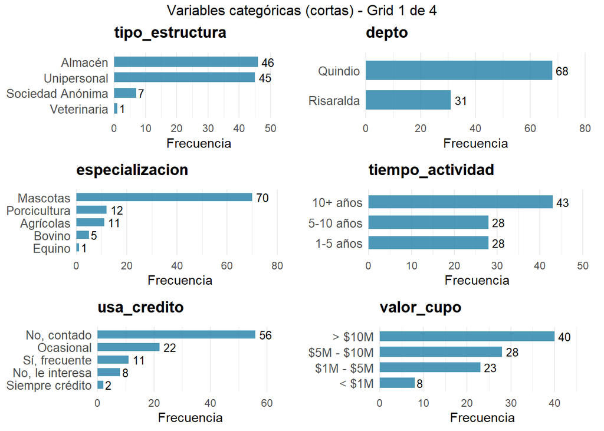

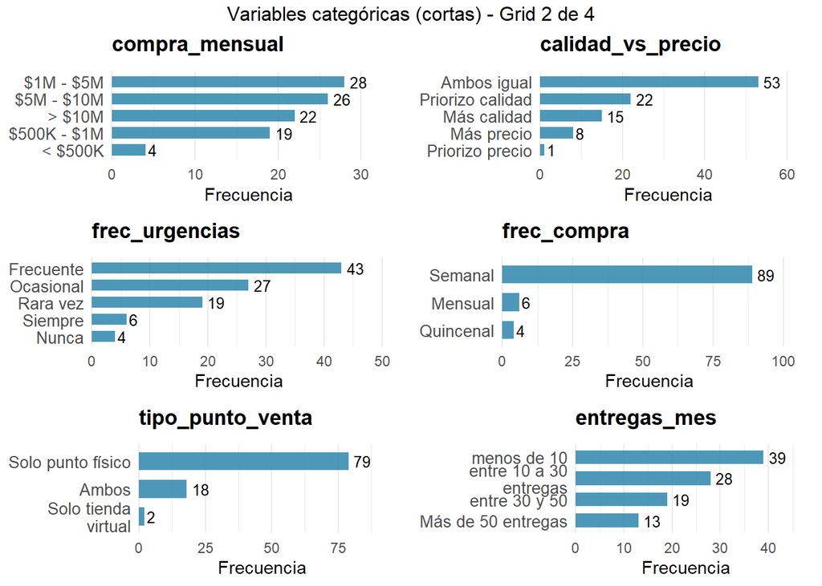

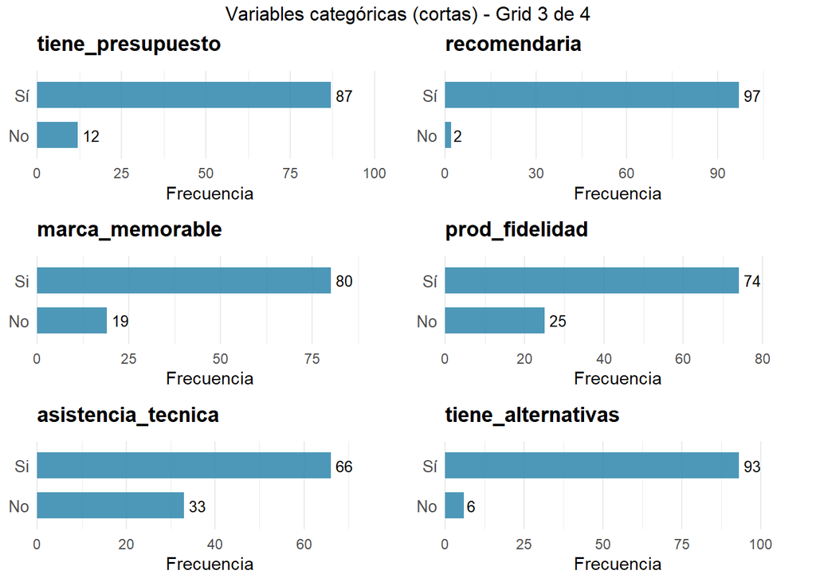

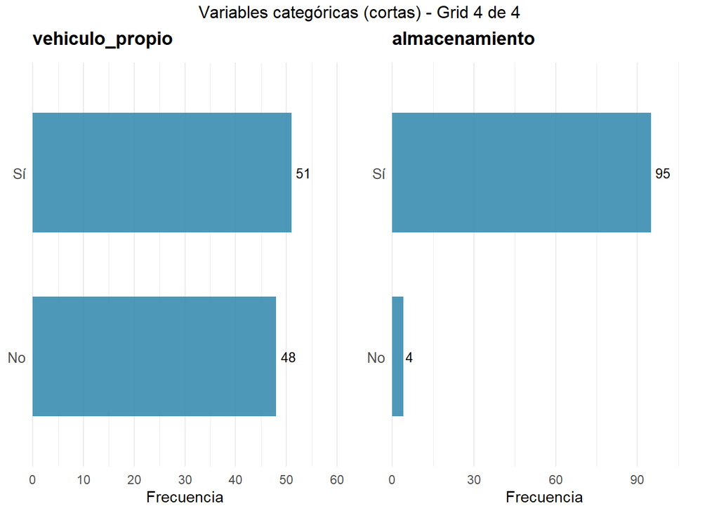

```r
#chunk1.7
# 5. VISUALIZACIÓN DE DISTRIBUCIONES


# Crear directorio para gráficos
if(!dir.exists("graficos_distribuciones")) {
  dir.create("graficos_distribuciones")
}


# 1.VERSIONES ABREVIADAS DE VARIABLES CON TEXTOS LARGOS
# ============================================


# copia de seguridad
datos_viz <- datos_limpios

# lineas_comerciales
if("lineas_comerciales" %in% names(datos_viz)) {
  datos_viz$lineas_comerciales_abrev <- datos_viz$lineas_comerciales
  # visualización de las primeras 2 líneas
  datos_viz$lineas_comerciales_abrev <- sapply(datos_viz$lineas_comerciales, function(x) {
    if(is.na(x) || x == "") return("Sin datos")
    partes <- strsplit(as.character(x), ",")[[1]]
    if(length(partes) <= 2) return(x)
    paste(paste(trimws(partes[1:2]), collapse = ", "), "...")
  })
}

# tiempo_actividad
if("tiempo_actividad" %in% names(datos_viz)) {
  datos_viz$tiempo_actividad_abrev <- datos_viz$tiempo_actividad
  datos_viz$tiempo_actividad_abrev <- case_when(
    datos_viz$tiempo_actividad == "10 años en adelante" ~ "10+ años",
    datos_viz$tiempo_actividad == "de 5 a 10 años" ~ "5-10 años",
    datos_viz$tiempo_actividad == "De 1 a 5 años" ~ "1-5 años",
    TRUE ~ datos_viz$tiempo_actividad
  )
}

# usa_credito
if("usa_credito" %in% names(datos_viz)) {
  datos_viz$usa_credito_abrev <- datos_viz$usa_credito
  datos_viz$usa_credito_abrev <- case_when(
    datos_viz$usa_credito == "Si, frecuentemente" ~ "Sí, frecuente",
    datos_viz$usa_credito == "No, prefiere pagar de contado" ~ "No, contado",
    datos_viz$usa_credito == "Ocasionalmente" ~ "Ocasional",
    datos_viz$usa_credito == "Siempre utiliza creditos" ~ "Siempre crédito",
    datos_viz$usa_credito == "No, pero le interesaría acceder a uno" ~ "No, le interesa",
    TRUE ~ datos_viz$usa_credito
  )
}

# valor_cupo
if("valor_cupo" %in% names(datos_viz)) {
  datos_viz$valor_cupo_abrev <- datos_viz$valor_cupo
  datos_viz$valor_cupo_abrev <- case_when(
    datos_viz$valor_cupo == "mayor a  $10'000.000" ~ "> $10M",
    datos_viz$valor_cupo == "Entre $5'000.000 y $10'000.000" ~ "$5M - $10M",
    datos_viz$valor_cupo == "Entre $1'000.000 y $5'000.000" ~ "$1M - $5M",
    datos_viz$valor_cupo == "Menor a $1'000.000" ~ "< $1M",
    TRUE ~ datos_viz$valor_cupo
  )
}

# compra_mensual
if("compra_mensual" %in% names(datos_viz)) {
  datos_viz$compra_mensual_abrev <- datos_viz$compra_mensual
  datos_viz$compra_mensual_abrev <- case_when(
    datos_viz$compra_mensual == "más de $10'000.000" ~ "> $10M",
    datos_viz$compra_mensual == "entre $5'000.000 y $10'000.000" ~ "$5M - $10M",
    datos_viz$compra_mensual == "entre $1'000.000 y $5'000.000" ~ "$1M - $5M",
    datos_viz$compra_mensual == "entre $500.000 y $1'000.000" ~ "$500K - $1M",
    datos_viz$compra_mensual == "menos de $500.000" ~ "< $500K",
    TRUE ~ datos_viz$compra_mensual
  )
}

# calidad_vs_precio
if("calidad_vs_precio" %in% names(datos_viz)) {
  datos_viz$calidad_vs_precio_abrev <- datos_viz$calidad_vs_precio
  datos_viz$calidad_vs_precio_abrev <- case_when(
    datos_viz$calidad_vs_precio == "Priorizo totalmente la calidad, incluso si el precio es más alto." ~ "Priorizo calidad",
    datos_viz$calidad_vs_precio == "Le doy más importancia a la calidad que al precio." ~ "Más calidad",
    datos_viz$calidad_vs_precio == "Ambos factores son igual de importantes." ~ "Ambos igual",
    datos_viz$calidad_vs_precio == "Le doy más importancia al precio que a la calidad." ~ "Más precio",
    datos_viz$calidad_vs_precio == "Priorizo totalmente el precio, incluso si la calidad es inferior." ~ "Priorizo precio",
    TRUE ~ datos_viz$calidad_vs_precio
  )
}

# frec_urgencias
if("frec_urgencias" %in% names(datos_viz)) {
  datos_viz$frec_urgencias_abrev <- datos_viz$frec_urgencias
  datos_viz$frec_urgencias_abrev <- case_when(
    datos_viz$frec_urgencias == "Siempre" ~ "Siempre",
    datos_viz$frec_urgencias == "Frecuentemente" ~ "Frecuente",
    datos_viz$frec_urgencias == "Ocasionalmente" ~ "Ocasional",
    datos_viz$frec_urgencias == "Muy rara vez" ~ "Rara vez",
    datos_viz$frec_urgencias == "Nunca" ~ "Nunca",
    TRUE ~ datos_viz$frec_urgencias
  )
}

# cond_permanencia
if("cond_permanencia" %in% names(datos_viz)) {
  datos_viz$cond_permanencia_abrev <- datos_viz$cond_permanencia
  # Tomar solo los primeros 20 caracteres o primera categoría
  datos_viz$cond_permanencia_abrev <- sapply(datos_viz$cond_permanencia, function(x) {
    if(is.na(x) || x == "") return("Sin datos")
    partes <- strsplit(as.character(x), ",")[[1]]
    if(length(partes) <= 1) return(substr(x, 1, 20))
    paste(trimws(partes[1]), "...")
  })
}

# publicidad
if("publicidad" %in% names(datos_viz)) {
  datos_viz$publicidad_abrev <- datos_viz$publicidad
  # Tomar solo la primera categoría
  datos_viz$publicidad_abrev <- sapply(datos_viz$publicidad, function(x) {
    if(is.na(x) || x == "") return("Sin datos")
    partes <- strsplit(as.character(x), ",")[[1]]
    if(length(partes) <= 1) return(substr(x, 1, 25))
    paste(trimws(partes[1]), "...")
  })
}

#valor_distribuidor
if("valor_distribuidor" %in% names(datos_viz)) {
  datos_viz$valor_distribuidor_abrev <- datos_viz$valor_distribuidor
  # Tomar solo los primeros 20 caracteres
  datos_viz$valor_distribuidor_abrev <- sapply(datos_viz$valor_distribuidor, function(x) {
    if(is.na(x) || x == "") return("Sin datos")
    if(nchar(x) <= 25) return(x)
    paste(substr(x, 1, 25), "...")
  })
}

# 2. DEFINIR LISTAS DE VARIABLES POR TIPO


# Variables numéricas originales
vars_numericas <- datos_viz %>%
  select(where(is.numeric)) %>%
  names()

# Variables categóricas con versiones abreviadas
vars_categoricas_originales <- c(
  "tipo_estructura", "depto", "especializacion",
  "lineas_comerciales_abrev", "tiempo_actividad_abrev",
  "usa_credito_abrev", "valor_cupo_abrev", "compra_mensual_abrev",
  "calidad_vs_precio_abrev", "frec_urgencias_abrev", "frec_compra",
  "tipo_punto_venta", "entregas_mes", "tiene_presupuesto",
  "recomendaria", "marca_memorable", "prod_fidelidad",
  "asistencia_tecnica", "tiene_alternativas", "vehiculo_propio",
  "almacenamiento", "cond_permanencia_abrev", "publicidad_abrev",
  "valor_distribuidor_abrev"
)

# Filtrar variables que existen
vars_categoricas <- vars_categoricas_originales[vars_categoricas_originales %in% names(datos_viz)]

# 3. FUNCIÓN PARA CREAR GRÁFICOS

crear_grafico_categorico <- function(datos, variable, nombre_original = NULL) {

  freq_table <- as.data.frame(table(datos[[variable]], useNA = "ifany"))
  names(freq_table) <- c("categoria", "frecuencia")
  freq_table <- freq_table[!is.na(freq_table$categoria) & freq_table$categoria != "", ]

  if(nrow(freq_table) > 10) {
    freq_table <- freq_table[order(-freq_table$frecuencia), ][1:10, ]
  }
  freq_table <- freq_table[order(freq_table$frecuencia), ]
  freq_table$categoria <- factor(freq_table$categoria, levels = freq_table$categoria)

  titulo <- ifelse(is.null(nombre_original), variable, nombre_original)
  titulo <- gsub("_abrev", "", titulo)

  p <- ggplot(freq_table, aes(x = categoria, y = frecuencia)) +
    geom_col(fill = "#2E86AB", alpha = 0.85, width = 0.7) +
    geom_text(aes(label = frecuencia), hjust = -0.2, size = 3.3) +
    coord_flip(clip = "off") +
    scale_x_discrete(labels = function(x) str_wrap(x, width = 22)) +
    labs(title = titulo, x = NULL, y = "Frecuencia") +
    theme_minimal(base_size = 11) +
    theme(
      plot.title = element_text(size = 12, face = "bold", margin = margin(b = 8)),
      axis.text.y = element_text(size = 9),
      panel.grid.major.y = element_blank(),
      plot.margin = margin(5.5, 20, 5.5, 5.5)
    )
  return(p)
}

crear_grafico_numerico <- function(datos, variable) {
  p <- ggplot(datos, aes(x = .data[[variable]])) +
    geom_histogram(bins = 15, fill = "#2E86AB", color = "white", alpha = 0.85) +
    labs(title = variable, x = NULL, y = "Frecuencia") +
    theme_minimal(base_size = 11) +
    theme(
      plot.title = element_text(size = 12, face = "bold"),
      axis.text.x = element_text(size = 9),
      axis.text.y = element_text(size = 9)
    )
  return(p)
}


# 4. GENERAR GRÁFICOS POR GRUPOS
# ============================================

library(gridExtra)

# --- Separar variables categóricas por longitud de texto ---
# Variables con categorías cortas (Sí/No, pocas palabras) -> van en grid compacto
vars_cortas <- c(
  "tipo_estructura", "depto", "especializacion",
  "tiempo_actividad_abrev", "usa_credito_abrev", "valor_cupo_abrev",
  "compra_mensual_abrev", "calidad_vs_precio_abrev", "frec_urgencias_abrev",
  "frec_compra", "tipo_punto_venta", "entregas_mes", "tiene_presupuesto",
  "recomendaria", "marca_memorable", "prod_fidelidad",
  "asistencia_tecnica", "tiene_alternativas", "vehiculo_propio", "almacenamiento"
)

# Variables con texto largo o multi-respuesta -> van solas, a ancho completo
vars_largas <- c(
  "cond_permanencia_abrev", "publicidad_abrev",
  "valor_distribuidor_abrev", "lineas_comerciales_abrev"
)

vars_cortas <- intersect(vars_cortas, names(datos_viz))
vars_largas <- intersect(vars_largas, names(datos_viz))

# Función de gráfico ajustada: más espacio para el texto y el número
crear_grafico_categorico <- function(datos, variable, nombre_original = NULL,
                                      wrap_width = 25, base_size = 11) {

  freq_table <- as.data.frame(table(datos[[variable]], useNA = "ifany"))
  names(freq_table) <- c("categoria", "frecuencia")
  freq_table <- freq_table[!is.na(freq_table$categoria) & freq_table$categoria != "", ]

  if (nrow(freq_table) > 10) {
    freq_table <- freq_table[order(-freq_table$frecuencia), ][1:10, ]
  }
  freq_table <- freq_table[order(freq_table$frecuencia), ]
  freq_table$categoria <- factor(freq_table$categoria, levels = freq_table$categoria)

  titulo <- ifelse(is.null(nombre_original), variable, nombre_original)
  titulo <- gsub("_abrev", "", titulo)

  max_frec <- max(freq_table$frecuencia)

  ggplot(freq_table, aes(x = categoria, y = frecuencia)) +
    geom_col(fill = "#2E86AB", alpha = 0.85, width = 0.65) +
    geom_text(aes(label = frecuencia), hjust = -0.3, size = 3.4) +
    coord_flip(clip = "off") +
    # deja ~15% de espacio extra a la derecha para que el número no se corte
    scale_y_continuous(expand = expansion(mult = c(0, 0.18))) +
    scale_x_discrete(labels = function(x) str_wrap(x, width = wrap_width)) +
    labs(title = titulo, x = NULL, y = "Frecuencia") +
    theme_minimal(base_size = base_size) +
    theme(
      plot.title = element_text(size = 13, face = "bold", margin = margin(b = 10)),
      axis.text.y = element_text(size = 10, lineheight = 0.9),
      panel.grid.major.y = element_blank(),
      plot.margin = margin(5.5, 15, 5.5, 5.5)
    )
}

# --- 4.1 Grid compacto: variables de categorías cortas (3 columnas) ---
plots_cortas <- lapply(vars_cortas, function(v) {
  crear_grafico_categorico(datos_viz, v, v, wrap_width = 18)
})
names(plots_cortas) <- vars_cortas

if (length(plots_cortas) > 0) {
  n_grids <- ceiling(length(plots_cortas) / 6)
  for (g in 1:n_grids) {
    inicio <- (g - 1) * 6 + 1
    fin <- min(g * 6, length(plots_cortas))
    grid_plot <- do.call(grid.arrange,
                          c(plots_cortas[inicio:fin], ncol = 2,
                            top = paste("Variables categóricas (cortas) - Grid", g, "de", n_grids)))
    print(grid_plot)

  }
}
```

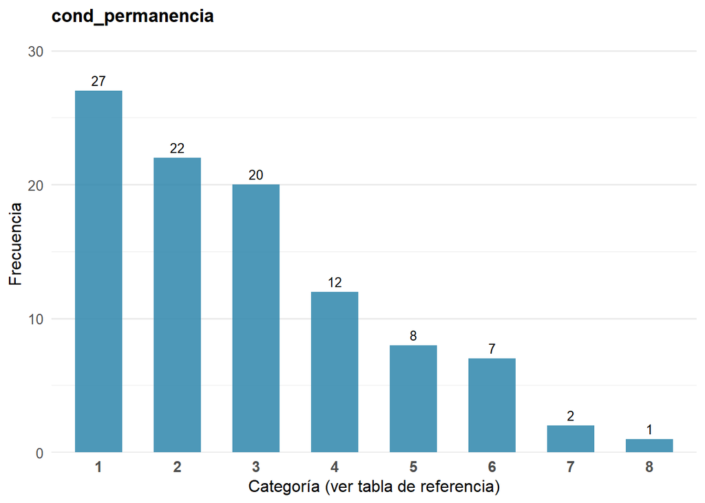

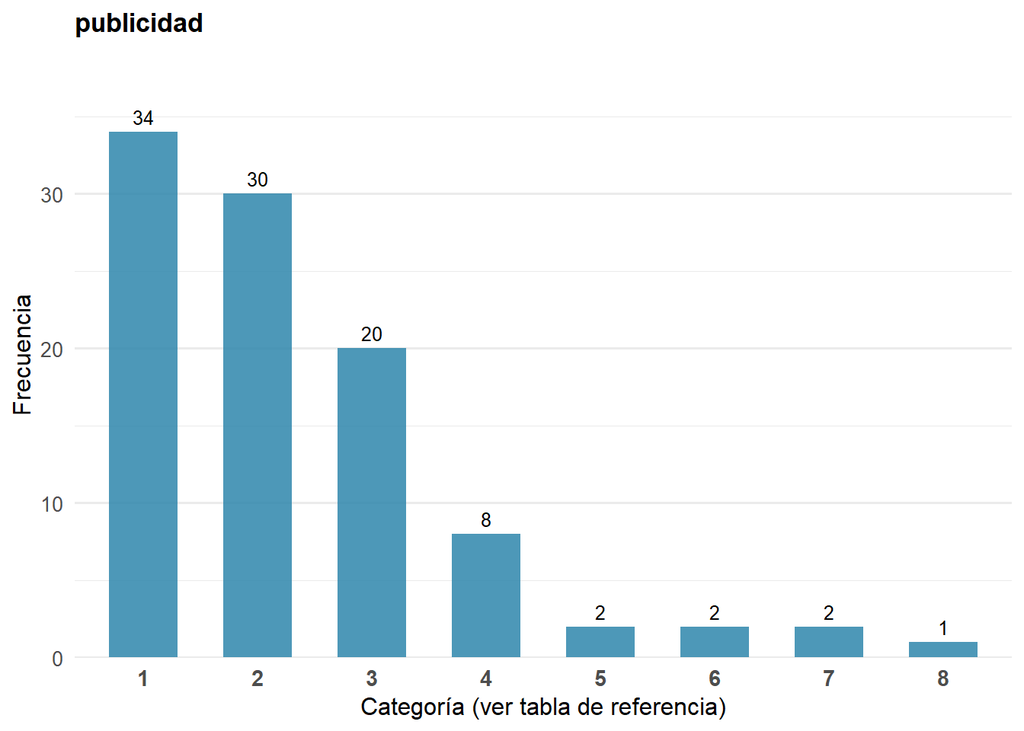

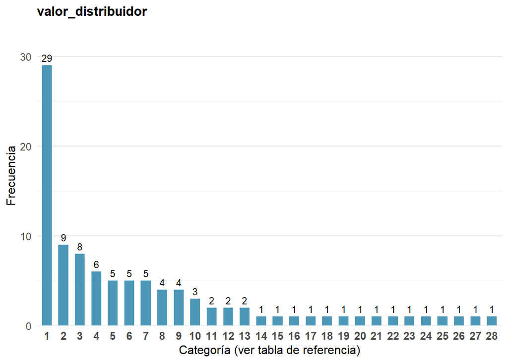

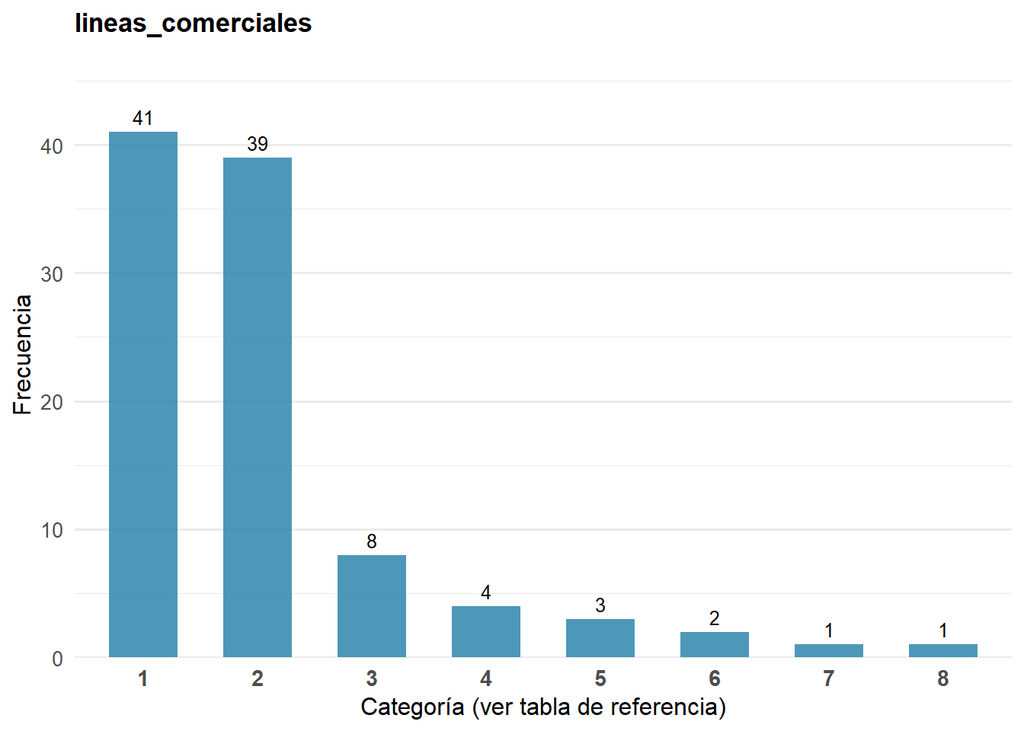

```r
# --- 4.2 Una figura completa por cada variable de texto largo, con códigos numéricos ---
# ============================================

diccionario_largas <- list()

crear_grafico_codificado_largo <- function(datos, variable, nombre_original) {

  freq_table <- as.data.frame(table(datos[[variable]], useNA = "ifany"))
  names(freq_table) <- c("categoria", "frecuencia")
  freq_table <- freq_table[!is.na(freq_table$categoria) & freq_table$categoria != "", ]
  freq_table <- freq_table[order(-freq_table$frecuencia), ]  # de mayor a menor frecuencia

  # Código numérico secuencial: se muestran TODAS las categorías, sin recortar
  freq_table$codigo <- seq_len(nrow(freq_table))
  freq_table$codigo_label <- factor(freq_table$codigo, levels = freq_table$codigo)

  titulo <- gsub("_abrev", "", nombre_original)

  p <- ggplot(freq_table, aes(x = codigo_label, y = frecuencia)) +
    geom_col(fill = "#2E86AB", alpha = 0.85, width = 0.6) +
    geom_text(aes(label = frecuencia), vjust = -0.5, size = 3.4) +
    scale_y_continuous(expand = expansion(mult = c(0, 0.15))) +
    labs(title = titulo, x = "Categoría (ver tabla de referencia)", y = "Frecuencia") +
    theme_minimal(base_size = 12) +
    theme(
      plot.title = element_text(size = 13, face = "bold", margin = margin(b = 8)),
      axis.text.x = element_text(size = 11, face = "bold"),
      axis.text.y = element_text(size = 10),
      panel.grid.major.x = element_blank()
    )

  list(plot = p,
       dict = data.frame(Codigo = freq_table$codigo, Categoria = freq_table$categoria))
}

for (v in vars_largas) {
  nombre_original <- gsub("_abrev", "", v)
  resultado <- crear_grafico_codificado_largo(datos_viz, v, v)
  print(resultado$plot)
  diccionario_largas[[nombre_original]] <- resultado$dict
}
```

```r
# 5. GRÁFICO ESPECÍFICO PARA OPCIONES MÚLTIPLES

cat("\nGenerando gráfico específico para opciones múltiples...\n")
```

```
##
## Generando gráfico específico para opciones múltiples...
```

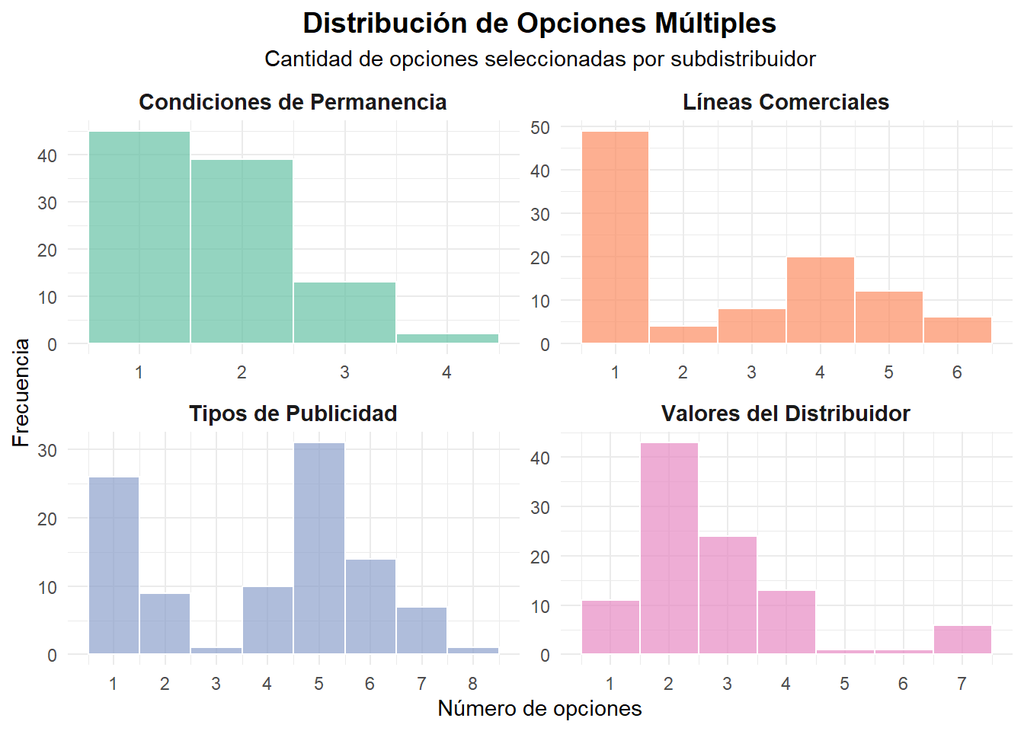

```r
vars_opciones <- c("num_valores_dist", "num_cond_perm", "num_tipos_publicidad", "num_lineas")
vars_opciones_existentes <- intersect(vars_opciones, names(datos_viz))

if(length(vars_opciones_existentes) > 0) {
  df_opciones <- datos_viz %>%
    select(all_of(vars_opciones_existentes)) %>%
    pivot_longer(everything(), names_to = "variable", values_to = "conteo") %>%
    mutate(
      conteo = as.numeric(conteo),
      variable_nombre = case_when(
        variable == "num_valores_dist" ~ "Valores del Distribuidor",
        variable == "num_cond_perm" ~ "Condiciones de Permanencia",
        variable == "num_tipos_publicidad" ~ "Tipos de Publicidad",
        variable == "num_lineas" ~ "Líneas Comerciales",
        TRUE ~ variable
      )
    )

  p_opciones <- ggplot(df_opciones, aes(x = conteo, fill = variable_nombre)) +
    geom_histogram(binwidth = 1, color = "white", alpha = 0.7) +
    facet_wrap(~variable_nombre, scales = "free", ncol = 2) +
    scale_x_continuous(breaks = scales::breaks_width(1)) +
    scale_fill_brewer(palette = "Set2")  +
    labs(title = "Distribución de Opciones Múltiples",
         subtitle = "Cantidad de opciones seleccionadas por subdistribuidor",
         x = "Número de opciones",
         y = "Frecuencia") +
    theme_minimal() +
    theme(legend.position = "none",
          plot.title = element_text(face = "bold", hjust = 0.5, size = 14),
          plot.subtitle = element_text(hjust = 0.5, size = 11),
          strip.text = element_text(face = "bold", size = 11))

  print(p_opciones)

}
```

```r
# 6. RESUMEN

cat("RESUMEN DE VISUALIZACIONES GENERADAS\n")
```

```
## RESUMEN DE VISUALIZACIONES GENERADAS
```

```r
cat("Gráficos generados:\n")
```

```
## Gráficos generados:
```

```r
cat("  Variables numéricas:", length(vars_numericas), "\n")
```

```
##   Variables numéricas: 34
```

```r
cat("  Opciones múltiples:", length(vars_opciones_existentes), "\n\n")
```

```
##   Opciones múltiples: 4
```

```r
# 7. GUARDAR CHECKPOINT

if(!dir.exists("checkpoints")) dir.create("checkpoints")
saveRDS(datos_viz, "checkpoints/datos_viz_con_abreviaciones.rds")
cat("Checkpoint guardado: checkpoints/datos_viz_con_abreviaciones.rds\n")
```

```
## Checkpoint guardado: checkpoints/datos_viz_con_abreviaciones.rds
```

```r
#chunk1.7b
library(kableExtra)
for (nombre in names(diccionario_largas)) {
  print(
    diccionario_largas[[nombre]] %>%
      kable(caption = paste("Referencia de códigos:", gsub("_", " ", nombre)), align = "c") %>%
      kable_styling(bootstrap_options = c("striped", "hover", "condensed"), full_width = FALSE)
  )
}
```

Referencia de códigos: cond permanencia

| Codigo | Categoria |
| --- | --- |
| 1 | Buena experiencia … |
| 2 | Fidelidad |
| 3 | Beneficios … |
| 4 | Buena experiencia |
| 5 | No hay mas alternati |
| 6 | Afiliación … |
| 7 | Beneficios |
| 8 | Afiliación |

Referencia de códigos: publicidad

| Codigo | Categoria |
| --- | --- |
| 1 | Material impreso (catalogos … |
| 2 | Correos promocionales … |
| 3 | Voceo y/o recomendaciones |
| 4 | Pautas de medios digitales … |
| 5 | Comerciales visuales y/o |
| 6 | Correos promocionales |
| 7 | Pautas de medios digitale |
| 8 | Comerciales visuales y/o radiales … |

Referencia de códigos: valor distribuidor

| Codigo | Categoria |
| --- | --- |
| 1 | Precio, Calidad |
| 2 | Precio, Calidad, Asistenc … |
| 3 | Precio, Calidad, Benefici … |
| 4 | Precio, Calidad, Variedad … |
| 5 | Calidad |
| 6 | Precio, Calidad, Ubicació … |
| 7 | Variedad en servicios y p … |
| 8 | Calidad, Variedad en serv … |
| 9 | Precio, Calidad, Atención … |
| 10 | Precio, Beneficios |
| 11 | Calidad, Ubicación |
| 12 | Precio, Variedad en servi … |
| 13 | Ubicación |
| 14 | Asistencia, Beneficios |
| 15 | Asistencia, Variedad en s … |
| 16 | Atención al cliente y asi … |
| 17 | Beneficios, Ubicación |
| 18 | Calidad, Asistencia, Aten … |
| 19 | Calidad, Asistencia, Vari … |
| 20 | Calidad, Atención al clie … |
| 21 | Calidad, Beneficios |
| 22 | Calidad, Beneficios, Aten … |
| 23 | Precio |
| 24 | Precio, Asistencia |
| 25 | Precio, Asistencia, Benef … |
| 26 | Precio, Asistencia, Varie … |
| 27 | Precio, Atención al clien … |
| 28 | Precio, Beneficios, Atenc … |

Referencia de códigos: lineas comerciales

| Codigo | Categoria |
| --- | --- |
| 1 | Mascotas |
| 2 | Bovino, Equino … |
| 3 | Agrícolas |
| 4 | Bovino, Porcicultura … |
| 5 | Equino, Porcicultura … |
| 6 | Mascotas, Otro |
| 7 | Equino, Mascotas |
| 8 | Porcicultura, Mascotas |

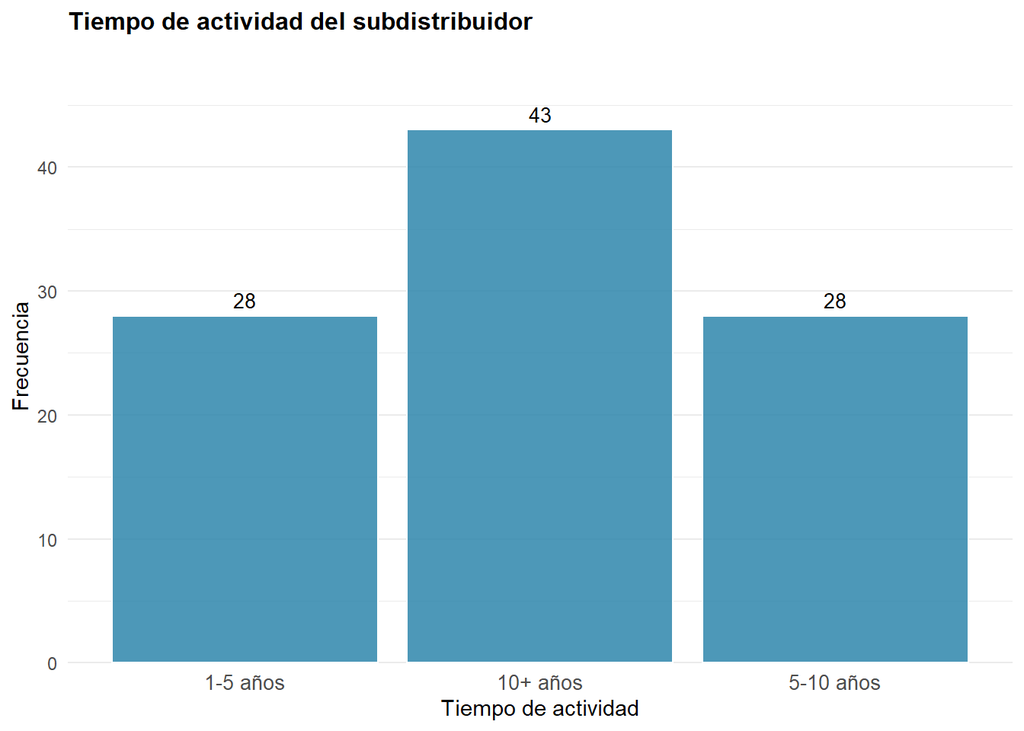

```r
#chunk1.8
# Barplot para tiempo_actividad

datos_viz_tiempo <- datos_limpios %>%
  mutate(
    tiempo_actividad_abrev = case_when(
      tiempo_actividad == "10 años en adelante" ~ "10+ años",
      tiempo_actividad == "de 5 a 10 años" ~ "5-10 años",
      tiempo_actividad == "De 1 a 5 años" ~ "1-5 años",
      TRUE ~ tiempo_actividad
    )
  )

ggplot(datos_viz_tiempo, aes(x = tiempo_actividad_abrev)) +
  geom_bar(fill = "#2E86AB", color = "white", alpha = 0.85) +
  geom_text(stat = "count", aes(label = after_stat(count)), vjust = -0.5, size = 3.5) +
  scale_y_continuous(expand = expansion(mult = c(0, 0.15))) +
  labs(title = "Tiempo de actividad del subdistribuidor",
       x = "Tiempo de actividad",
       y = "Frecuencia") +
  theme_minimal() +
  theme(
    plot.title = element_text(size = 12, face = "bold", margin = margin(b = 8)),
    axis.text.x = element_text(size = 10),
    axis.text.y = element_text(size = 9),
    panel.grid.major.x = element_blank()
  )
```

```r
#chunk1.9
# 5. VISUALIZACIÓN DE DISTRIBUCIONES

cat("GENERANDO VISUALIZACIONES DE DISTRIBUCIONES\n")
```

```
## GENERANDO VISUALIZACIONES DE DISTRIBUCIONES
```

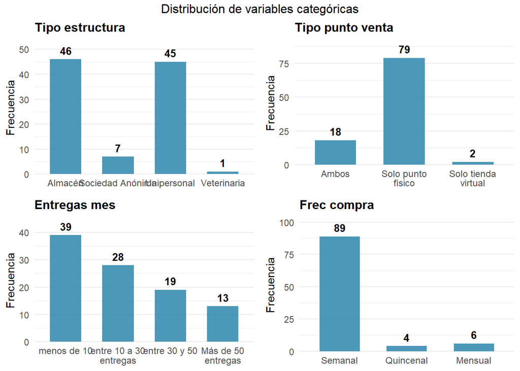

```r
# Crear directorio para gráficos
if(!dir.exists("graficos_distribuciones")) {
  dir.create("graficos_distribuciones")
}

# 1. CREAR DICCIONARIO DE CODIFICACIÓN PARA VARIABLES PROBLEMÁTICAS

datos_viz <- datos_limpios

# Diccionario para almacenar las correspondencias
diccionario_codigos <- list()

# 1. tipo_estructura
if("tipo_estructura" %in% names(datos_viz)) {
  tipos <- sort(unique(datos_viz$tipo_estructura[!is.na(datos_viz$tipo_estructura)]))
  codigos <- 1:length(tipos)
  datos_viz$tipo_estructura_cod <- as.numeric(factor(datos_viz$tipo_estructura, levels = tipos))
  diccionario_codigos$tipo_estructura <- data.frame(
    Codigo = codigos,
    Categoria = tipos
  )
}

# 2. lineas_comerciales - categoría principal
if("lineas_comerciales" %in% names(datos_viz)) {
  get_primera_linea <- function(x) {
    if(is.na(x) || x == "") return("Sin datos")
    partes <- trimws(strsplit(as.character(x), ",")[[1]])
    return(partes[1])
  }

  datos_viz$linea_principal <- sapply(datos_viz$lineas_comerciales, get_primera_linea)
  lineas <- sort(unique(datos_viz$linea_principal[!is.na(datos_viz$linea_principal)]))
  codigos <- 1:length(lineas)
  datos_viz$linea_principal_cod <- as.numeric(factor(datos_viz$linea_principal, levels = lineas))
  diccionario_codigos$lineas_comerciales <- data.frame(
    Codigo = codigos,
    Categoria = lineas
  )
}

# 3. usa_credito (orden lógico: de menor a mayor uso)
if("usa_credito" %in% names(datos_viz)) {
  creditos <- c("No, prefiere pagar de contado",
                "No, pero le interesaría acceder a uno",
                "Ocasionalmente",
                "Si, frecuentemente",
                "Siempre utiliza creditos")
  creditos <- creditos[creditos %in% unique(datos_viz$usa_credito)]
  codigos <- 1:length(creditos)
  datos_viz$usa_credito_cod <- as.numeric(factor(datos_viz$usa_credito, levels = creditos))
  diccionario_codigos$usa_credito <- data.frame(
    Codigo = codigos,
    Categoria = creditos
  )
}

# 4. calidad_vs_precio (orden lógico: de priorizar precio a priorizar calidad)
if("calidad_vs_precio" %in% names(datos_viz)) {
  calidades <- c("Priorizo totalmente el precio, incluso si la calidad es inferior.",
                 "Le doy más importancia al precio que a la calidad.",
                 "Ambos factores son igual de importantes.",
                 "Le doy más importancia a la calidad que al precio.",
                 "Priorizo totalmente la calidad, incluso si el precio es más alto.")
  calidades <- calidades[calidades %in% unique(datos_viz$calidad_vs_precio)]
  codigos <- 1:length(calidades)
  datos_viz$calidad_vs_precio_cod <- as.numeric(factor(datos_viz$calidad_vs_precio, levels = calidades))
  diccionario_codigos$calidad_vs_precio <- data.frame(
    Codigo = codigos,
    Categoria = calidades
  )
}

# 5. tipo_punto_venta
if("tipo_punto_venta" %in% names(datos_viz)) {
  puntos <- sort(unique(datos_viz$tipo_punto_venta[!is.na(datos_viz$tipo_punto_venta)]))
  codigos <- 1:length(puntos)
  datos_viz$tipo_punto_venta_cod <- as.numeric(factor(datos_viz$tipo_punto_venta, levels = puntos))
  diccionario_codigos$tipo_punto_venta <- data.frame(
    Codigo = codigos,
    Categoria = puntos
  )
}

# 6. entregas_mes (orden lógico: de menor a mayor)
if("entregas_mes" %in% names(datos_viz)) {
  entregas <- c("menos de 10",
                "entre 10 a 30 entregas",
                "entre 30 y 50",
                "Más de 50 entregas")
  entregas <- entregas[entregas %in% unique(datos_viz$entregas_mes)]
  codigos <- 1:length(entregas)
  datos_viz$entregas_mes_cod <- as.numeric(factor(datos_viz$entregas_mes, levels = entregas))
  diccionario_codigos$entregas_mes <- data.frame(
    Codigo = codigos,
    Categoria = entregas
  )
}

# 7. frec_compra (orden lógico: de mayor a menor frecuencia)
if("frec_compra" %in% names(datos_viz)) {
  frecuencias <- c("Semanal", "Quincenal", "Mensual", "Trimestral")
  frecuencias <- frecuencias[frecuencias %in% unique(datos_viz$frec_compra)]
  codigos <- 1:length(frecuencias)
  datos_viz$frec_compra_cod <- as.numeric(factor(datos_viz$frec_compra, levels = frecuencias))
  diccionario_codigos$frec_compra <- data.frame(
    Codigo = codigos,
    Categoria = frecuencias
  )
}

# 8. frec_urgencias (orden lógico: de mayor a menor)
if("frec_urgencias" %in% names(datos_viz)) {
  urgencias <- c("Siempre", "Frecuentemente", "Ocasionalmente", "Muy rara vez", "Nunca")
  urgencias <- urgencias[urgencias %in% unique(datos_viz$frec_urgencias)]
  codigos <- 1:length(urgencias)
  datos_viz$frec_urgencias_cod <- as.numeric(factor(datos_viz$frec_urgencias, levels = urgencias))
  diccionario_codigos$frec_urgencias <- data.frame(
    Codigo = codigos,
    Categoria = urgencias
  )
}


# 2. FUNCIÓN PARA CREAR GRÁFICOS CON ETIQUETAS REALES
# ============================================

crear_grafico_categorico_cod <- function(datos, variable_cod, variable_original, dict, wrap_width = 20) {

  freq_table <- as.data.frame(table(datos[[variable_cod]], useNA = "ifany"))
  names(freq_table) <- c("codigo", "frecuencia")
  freq_table <- freq_table[!is.na(freq_table$codigo), ]
  freq_table$codigo <- as.numeric(as.character(freq_table$codigo))

  # Unir con el diccionario para traer la categoría real
  freq_table <- merge(freq_table, dict, by.x = "codigo", by.y = "Codigo")
  freq_table <- freq_table[order(freq_table$codigo), ]
  freq_table$Categoria <- factor(freq_table$Categoria, levels = freq_table$Categoria)

  titulo <- gsub("_", " ", variable_original)
  titulo <- paste0(toupper(substr(titulo, 1, 1)), substr(titulo, 2, nchar(titulo)))

  ggplot(freq_table, aes(x = Categoria, y = frecuencia)) +
    geom_col(fill = "#2E86AB", alpha = 0.85, width = 0.6) +
    geom_text(aes(label = frecuencia), vjust = -0.6, size = 3.5, fontface = "bold") +
    scale_x_discrete(labels = function(x) str_wrap(x, width = wrap_width)) +
    scale_y_continuous(expand = expansion(mult = c(0, 0.15))) +
    labs(title = titulo, x = NULL, y = "Frecuencia") +
    theme_minimal(base_size = 11) +
    theme(
      plot.title = element_text(size = 12, face = "bold", margin = margin(b = 8)),
      axis.text.x = element_text(size = 9, lineheight = 0.85),
      panel.grid.major.x = element_blank()
    )
}

# 3. GENERACIÓN DE GRÁFICOS, SEPARANDO POR CANTIDAD DE CATEGORÍAS
# ============================================

library(gridExtra)

variables_codificadas <- list(
  "tipo_estructura"    = "tipo_estructura_cod",
  "lineas_comerciales" = "linea_principal_cod",
  "usa_credito"        = "usa_credito_cod",
  "calidad_vs_precio"  = "calidad_vs_precio_cod",
  "tipo_punto_venta"   = "tipo_punto_venta_cod",
  "entregas_mes"       = "entregas_mes_cod",
  "frec_compra"        = "frec_compra_cod",
  "frec_urgencias"     = "frec_urgencias_cod"
)

variables_existentes <- names(variables_codificadas)[
  sapply(variables_codificadas, function(x) x %in% names(datos_viz))
]

# Separar por cantidad de categorías: pocas -> grid, muchas -> ancho completo
n_categorias <- sapply(diccionario_codigos, nrow)
vars_pocas  <- intersect(variables_existentes, names(n_categorias)[n_categorias <= 4])
vars_muchas <- intersect(variables_existentes, names(n_categorias)[n_categorias > 4])

# --- Grid compacto para variables con pocas categorías ---
plots_pocas <- list()
for (var in vars_pocas) {
  plots_pocas[[var]] <- crear_grafico_categorico_cod(
    datos_viz, variables_codificadas[[var]], var, diccionario_codigos[[var]], wrap_width = 16
  )
}

if (length(plots_pocas) > 0) {
  ncol_grid <- min(2, length(plots_pocas))
  nrow_grid <- ceiling(length(plots_pocas) / ncol_grid)
  grid_pocas <- do.call(grid.arrange,
                         c(plots_pocas, ncol = ncol_grid,
                           top = "Distribución de variables categóricas"))
  print(grid_pocas)

}
```

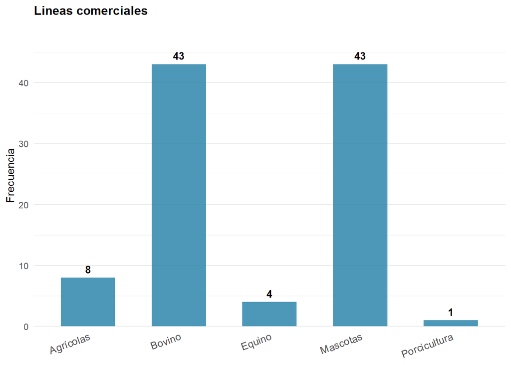

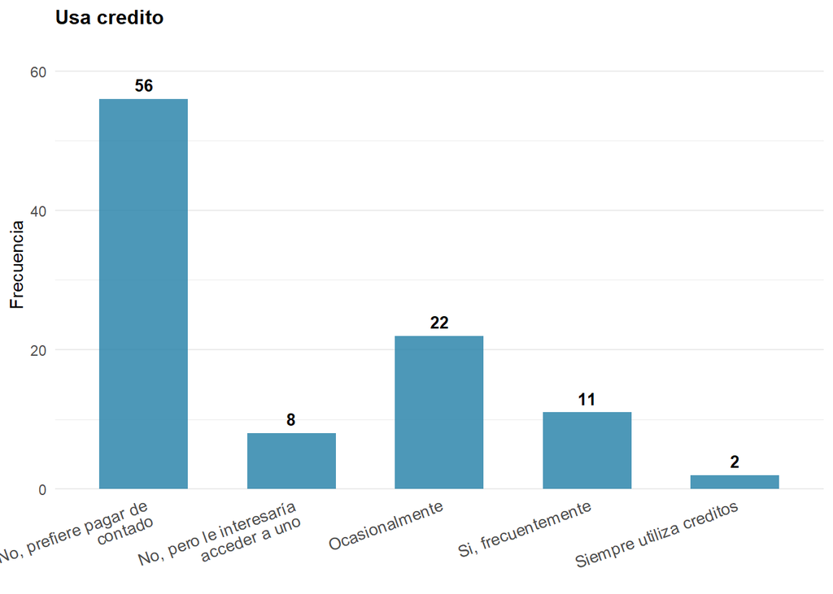

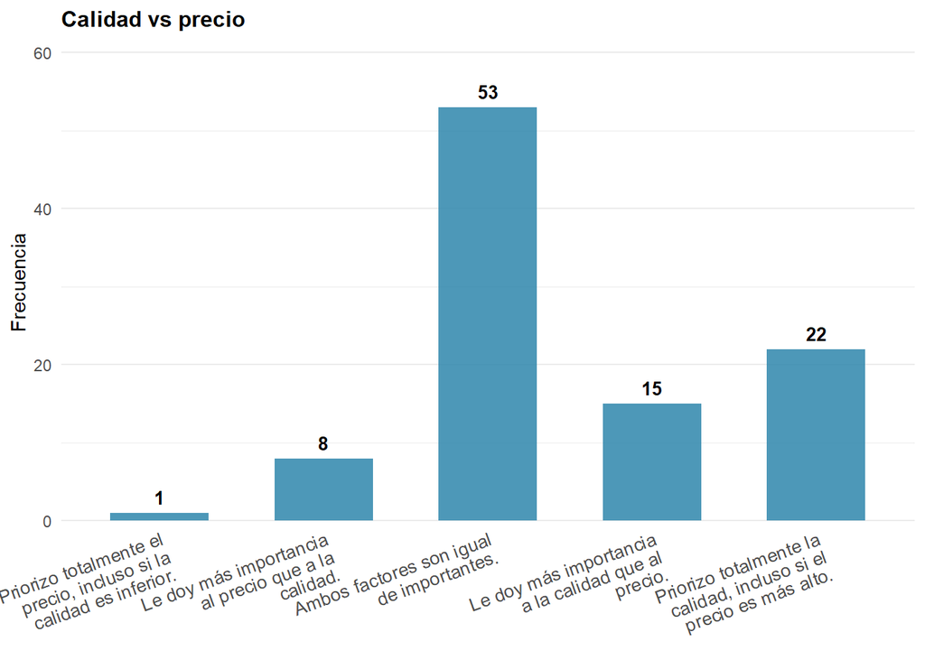

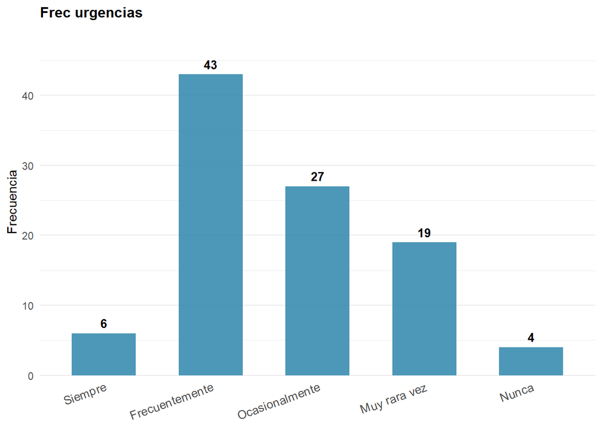

```r
# --- Gráfico individual a ancho completo para variables con muchas categorías ---
for (var in vars_muchas) {
  p <- crear_grafico_categorico_cod(
    datos_viz, variables_codificadas[[var]], var, diccionario_codigos[[var]], wrap_width = 24
  ) + theme(axis.text.x = element_text(size = 10, angle = 20, hjust = 1))
  print(p)

}
```

```r
# 4. GENERACION TABLA DE REFERENCIA DE CÓDIGOS



library(kableExtra)
for (var in names(diccionario_codigos)) {
  print(
    diccionario_codigos[[var]] %>%
      kable(caption = paste("Códigos:", gsub("_", " ", var)), align = "c") %>%
      kable_styling(bootstrap_options = c("striped", "hover", "condensed"), full_width = FALSE)
  )
}
```

Códigos: tipo estructura

| Codigo | Categoria |
| --- | --- |
| 1 | Almacén |
| 2 | Sociedad Anónima |
| 3 | Unipersonal |
| 4 | Veterinaria |

Códigos: lineas comerciales

| Codigo | Categoria |
| --- | --- |
| 1 | Agrícolas |
| 2 | Bovino |
| 3 | Equino |
| 4 | Mascotas |
| 5 | Porcicultura |

Códigos: usa credito

| Codigo | Categoria |
| --- | --- |
| 1 | No, prefiere pagar de contado |
| 2 | No, pero le interesaría acceder a uno |
| 3 | Ocasionalmente |
| 4 | Si, frecuentemente |
| 5 | Siempre utiliza creditos |

Códigos: calidad vs precio

| Codigo | Categoria |
| --- | --- |
| 1 | Priorizo totalmente el precio, incluso si la calidad es inferior. |
| 2 | Le doy más importancia al precio que a la calidad. |
| 3 | Ambos factores son igual de importantes. |
| 4 | Le doy más importancia a la calidad que al precio. |
| 5 | Priorizo totalmente la calidad, incluso si el precio es más alto. |

Códigos: tipo punto venta

| Codigo | Categoria |
| --- | --- |
| 1 | Ambos |
| 2 | Solo punto físico |
| 3 | Solo tienda virtual |

Códigos: entregas mes

| Codigo | Categoria |
| --- | --- |
| 1 | menos de 10 |
| 2 | entre 10 a 30 entregas |
| 3 | entre 30 y 50 |
| 4 | Más de 50 entregas |

Códigos: frec compra

| Codigo | Categoria |
| --- | --- |
| 1 | Semanal |
| 2 | Quincenal |
| 3 | Mensual |

Códigos: frec urgencias

| Codigo | Categoria |
| --- | --- |
| 1 | Siempre |
| 2 | Frecuentemente |
| 3 | Ocasionalmente |
| 4 | Muy rara vez |
| 5 | Nunca |

```r
cat("RESUMEN DE CODIFICACIÓN:\n")
```

RESUMEN DE CODIFICACIÓN:

```r
cat("  Total variables codificadas:", length(diccionario_codigos), "\n")
```

Total variables codificadas: 8

```r
for(var in names(diccionario_codigos)) {
  cat(paste0("  - ", var, ": ", nrow(diccionario_codigos[[var]]), " categorías\n"))
}
```

- tipo_estructura: 4 categorías
- lineas_comerciales: 5 categorías
- usa_credito: 5 categorías
- calidad_vs_precio: 5 categorías
- tipo_punto_venta: 3 categorías
- entregas_mes: 4 categorías
- frec_compra: 3 categorías
- frec_urgencias: 5 categorías

```r
#chunk1.9b
# 6. VISUALIZACIÓN DE VARIABLES NUMÉRICAS CONTINUAS Y DISCRETAS
# (excluye variables ya graficadas en chunk1.7 y chunk1.9)

vars_numericas_puras <- datos_limpios %>%
  select(where(is.numeric)) %>%
  select(-matches("_num$"), -matches("_cod$"), -matches("^num_")) %>%
  names()

cat("Variables numéricas detectadas:\n")
```

```
## Variables numéricas detectadas:
```

```r
print(vars_numericas_puras)
```

```
## [1] "n_empleados"         "facil_credito"       "prob_recompra"
## [4] "satis_frecuencia"    "infl_descuentos"     "encuentra_productos"
## [7] "tiempo_proveedor"    "ventas_mes"          "medida_almacen"
```

```r
# Clasificar automáticamente: discreta (tipo Likert, <=7 valores enteros) vs continua
detectar_tipo <- function(x) {
  vals <- unique(na.omit(x))
  if (length(vals) <= 7 && all(vals == floor(vals))) "discreta" else "continua"
}

tipos_var <- sapply(datos_limpios[vars_numericas_puras], detectar_tipo)
vars_discretas <- names(tipos_var[tipos_var == "discreta"])
vars_continuas <- names(tipos_var[tipos_var == "continua"])

cat("\n  Discretas (tipo Likert):", paste(vars_discretas, collapse = ", "), "\n")
```

```
##
##   Discretas (tipo Likert): facil_credito, prob_recompra, satis_frecuencia, infl_descuentos, encuentra_productos
```

```r
cat("  Continuas:", paste(vars_continuas, collapse = ", "), "\n")
```

```
##   Continuas: n_empleados, tiempo_proveedor, ventas_mes, medida_almacen
```

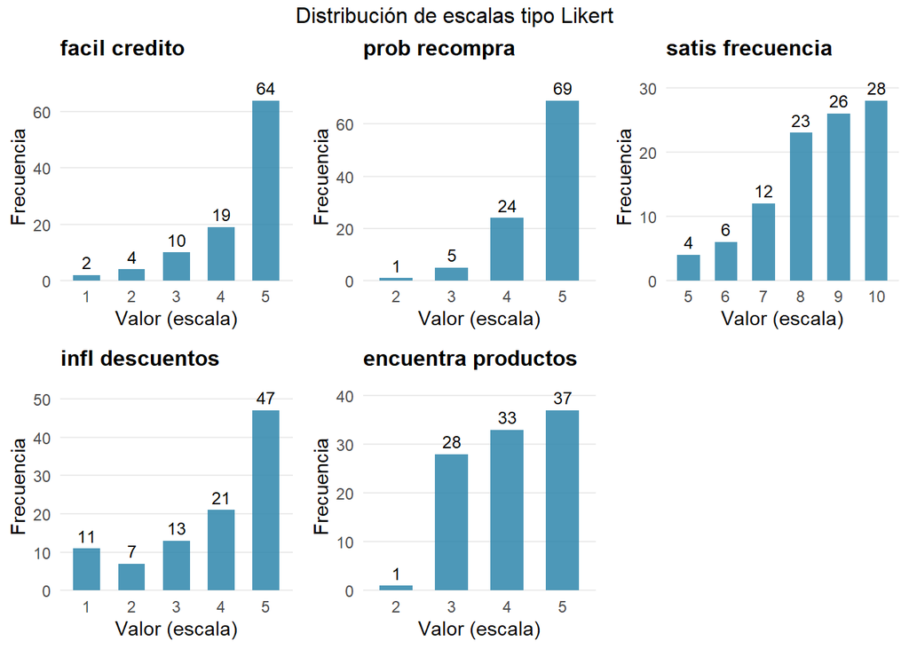

```r
# --- Gráfico para variables discretas: barras alineadas a cada valor entero ---
crear_grafico_discreto <- function(datos, variable) {
  freq_table <- as.data.frame(table(datos[[variable]], useNA = "no"))
  names(freq_table) <- c("valor", "frecuencia")

  ggplot(freq_table, aes(x = valor, y = frecuencia)) +
    geom_col(fill = "#2E86AB", alpha = 0.85, width = 0.6) +
    geom_text(aes(label = frecuencia), vjust = -0.5, size = 3.3) +
    scale_y_continuous(expand = expansion(mult = c(0, 0.15))) +
    labs(title = gsub("_", " ", variable), x = "Valor (escala)", y = "Frecuencia") +
    theme_minimal(base_size = 11) +
    theme(
      plot.title = element_text(size = 12, face = "bold", margin = margin(b = 8)),
      axis.text = element_text(size = 9),
      panel.grid.minor = element_blank(),
      panel.grid.major.x = element_blank()
    )
}

# --- Gráfico para variables continuas: binwidth adaptado + formato numérico legible ---
crear_grafico_continuo <- function(datos, variable) {
  x <- na.omit(datos[[variable]])
  # Cortes "redondos": se usan como bordes de barra Y como marcas del eje,
  # así quedan siempre alineados entre sí
  cortes <- pretty(x, n = 8)

  ggplot(datos, aes(x = .data[[variable]])) +
    geom_histogram(breaks = cortes, closed = "left",
                    fill = "#2E86AB", color = "white", alpha = 0.85) +
    scale_x_continuous(breaks = cortes,
                        labels = scales::label_number(big.mark = ".", decimal.mark = ",")) +
    labs(title = gsub("_", " ", variable), x = NULL, y = "Frecuencia") +
    theme_minimal(base_size = 11) +
    theme(
      plot.title = element_text(size = 12, face = "bold", margin = margin(b = 8)),
      axis.text.x = element_text(size = 9),
      axis.text.y = element_text(size = 9),
      panel.grid.minor = element_blank()
    )
}

library(gridExtra)

# --- Grid de variables discretas ---
if (length(vars_discretas) > 0) {
  plots_discretas <- lapply(vars_discretas, function(v) crear_grafico_discreto(datos_limpios, v))
  names(plots_discretas) <- vars_discretas
  ncol_grid <- min(3, length(plots_discretas))
  nrow_grid <- ceiling(length(plots_discretas) / ncol_grid)
  grid_discretas <- do.call(grid.arrange,
                             c(plots_discretas, ncol = ncol_grid,
                               top = "Distribución de escalas tipo Likert"))
  print(grid_discretas)

}
```

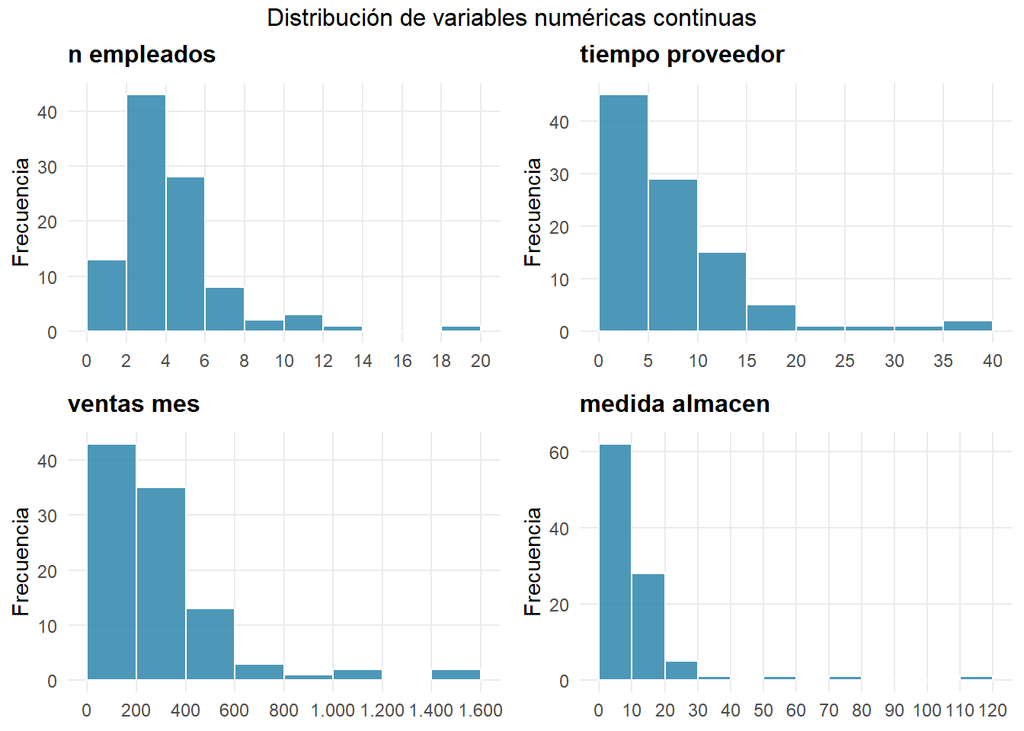

```r
# --- Grid de variables continuas ---
if (length(vars_continuas) > 0) {
  plots_continuas <- lapply(vars_continuas, function(v) crear_grafico_continuo(datos_limpios, v))
  names(plots_continuas) <- vars_continuas
  ncol_grid <- min(2, length(plots_continuas))
  nrow_grid <- ceiling(length(plots_continuas) / ncol_grid)
  grid_continuas <- do.call(grid.arrange,
                             c(plots_continuas, ncol = ncol_grid,
                               top = "Distribución de variables numéricas continuas"))
  print(grid_continuas)

}
```

Seleccion de variables para el PCA

```r
#chunk1.10
# Variables que NO entrarán al PCA (Se usaran para el perfilado)
vars_descartadas_pca <- c(
  # Originales textuales (ya transformadas)
  "tiempo_actividad", "valor_cupo", "compra_mensual", "calidad_vs_precio",
  "frec_compra", "frec_urgencias", "tiempo_espera", "almacenamiento",
  "tiene_alternativas", "tiene_presupuesto", "prod_fidelidad", "marca_memorable",
  "asistencia_tecnica", "vehiculo_propio", "recomendaria", "tipo_punto_venta",
  "facil_credito", "prob_recompra", "infl_descuentos", "encuentra_productos",
  "satis_frecuencia",

  # Categóricas nominales (NO van al PCA)
  "tipo_estructura", "depto", "ubicacion_extra", "area_acceso",
  "lineas_comerciales", "especializacion", "usa_credito", "publicidad",
  "entregas_mes", "valor_distribuidor", "cond_permanencia",

  # Otras
  "medida_almacen"
)

# Variables seleccionadas para PCA
vars_pca <- setdiff(names(datos_limpios), vars_descartadas_pca)

cat("Variables seleccionadas para PCA:\n")
```

```
## Variables seleccionadas para PCA:
```

```r
print(vars_pca)
```

```
##  [1] "n_empleados"             "n_clientes"
##  [3] "tiempo_proveedor"        "ventas_mes"
##  [5] "tiempo_actividad_num"    "valor_cupo_num"
##  [7] "compra_mensual_num"      "calidad_vs_precio_num"
##  [9] "frec_compra_num"         "frec_urgencias_num"
## [11] "tiempo_espera_num"       "almacenamiento_num"
## [13] "tiene_alternativas_num"  "tiene_presupuesto_num"
## [15] "prod_fidelidad_num"      "marca_memorable_num"
## [17] "asistencia_tecnica_num"  "vehiculo_propio_num"
## [19] "recomendaria_num"        "tipo_punto_venta_num"
## [21] "facil_credito_num"       "prob_recompra_num"
## [23] "infl_descuentos_num"     "encuentra_productos_num"
## [25] "satis_frecuencia_num"    "num_valores_dist"
## [27] "num_cond_perm"           "num_tipos_publicidad"
## [29] "num_lineas"
```

```r
# Crear dataset para PCA
datos_pca <- datos_limpios %>%
  select(all_of(vars_pca)) %>%
  # Asegurar que todas sean numéricas
  mutate(across(everything(), as.numeric))

# Verificar estructura
glimpse(datos_pca)
```

```
## Rows: 99
## Columns: 29
## $ n_empleados             <dbl> 3, 4, 3, 1, 5, 8, 10, 4, 1, 5, 1, 1, 3, 2, 2, …
## $ n_clientes              <dbl> 60, 50, 50, 100, 60, 100, 100, 150, 50, 100, 1…
## $ tiempo_proveedor        <dbl> 40, 35, 10, 3, 3, 15, 3, 9, 3, 10, 3, 4, 4, 6,…
## $ ventas_mes              <dbl> 0, 96, 250, 300, 50, 0, 100, 150, 200, 150, 10…
## $ tiempo_actividad_num    <dbl> 3, 3, 3, 1, 1, 3, 1, 3, 1, 3, 2, 1, 2, 2, 1, 1…
## $ valor_cupo_num          <dbl> 4, 4, 4, 1, 4, 3, 3, 1, 2, 4, 4, 2, 2, 2, 1, 2…
## $ compra_mensual_num      <dbl> 5, 5, 3, 5, 4, 5, 3, 3, 2, 4, 1, 3, 2, 3, 1, 2…
## $ calidad_vs_precio_num   <dbl> 3, 3, 3, 5, 1, 3, 3, 5, 4, 5, 3, 3, 3, 4, 2, 3…
## $ frec_compra_num         <dbl> 1, 1, 1, 1, 1, 1, 1, 1, 2, 1, 1, 1, 1, 1, 2, 1…
## $ frec_urgencias_num      <dbl> 2, 5, 4, 4, 1, 1, 1, 3, 2, 2, 4, 4, 3, 2, 3, 2…
## $ tiempo_espera_num       <dbl> 2, 1, 1, 1, 2, 1, 2, 1, 3, 2, 1, 2, 2, 2, 2, 2…
## $ almacenamiento_num      <dbl> 1, 1, 1, 1, 1, 1, 1, 1, 1, 1, 1, 1, 1, 1, 1, 1…
## $ tiene_alternativas_num  <dbl> 1, 0, 1, 0, 1, 1, 0, 1, 1, 1, 1, 1, 1, 1, 1, 1…
```

[output cut: 16 more lines]

# 2. ANALISIS EXPLORATORIO DE LOS DATOS

Exploracion de datos faltantes

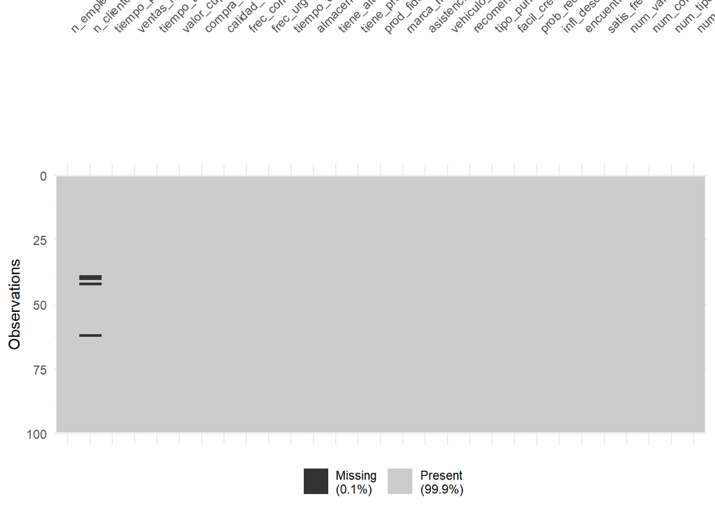

```r
#chunk 2.1

# Visualizar datos faltantes
vis_miss(datos_pca)
```

```r
# Resumen de NAs
nas_summary <- datos_pca %>%
  summarise(across(everything(), ~sum(is.na(.)))) %>%
  pivot_longer(everything(), names_to = "variable", values_to = "nas") %>%
  filter(nas > 0) %>%
  mutate(porcentaje = round(nas / nrow(datos_pca) * 100, 2))

print("Variables con datos faltantes:")
```

```
## [1] "Variables con datos faltantes:"
```

```r
print(nas_summary)
```

```
## # A tibble: 1 × 3
##   variable     nas porcentaje
##   <chr>      <int>      <dbl>
## 1 n_clientes     4       4.04
```

```r
# Tabla combinada: variable, cantidad de NA, y método de imputación aplicado
tabla_imputacion <- nas_summary %>%
  mutate(metodo = ifelse(variable %in% c("n_clientes", "ventas_mes", "medida_almacen"),
                          "Mediana", "Media"))
print(tabla_imputacion)
```

```
## # A tibble: 1 × 4
##   variable     nas porcentaje metodo
##   <chr>      <int>      <dbl> <chr>
## 1 n_clientes     4       4.04 Mediana
```

Imputacion de datos faltantes

```r
#chunk2.2
# Función de imputación
imputar_datos <- function(data) {
  data_imputada <- data

  for (col in names(data_imputada)) {
    if (sum(is.na(data_imputada[[col]])) > 0) {
      # Para variables con outliers potenciales, usar mediana
      if (col %in% c("n_clientes", "ventas_mes", "medida_almacen")) {
        valor_imp <- median(data_imputada[[col]], na.rm = TRUE)
      } else {
        # Para el resto, usar media
        valor_imp <- mean(data_imputada[[col]], na.rm = TRUE)
      }
      data_imputada[[col]][is.na(data_imputada[[col]])] <- valor_imp
    }
  }
  return(data_imputada)
}

datos_completos <- imputar_datos(datos_pca)

# Verificar que no queden NAs
sum(is.na(datos_completos))
```

```
## [1] 0
```

Analisis de outliers

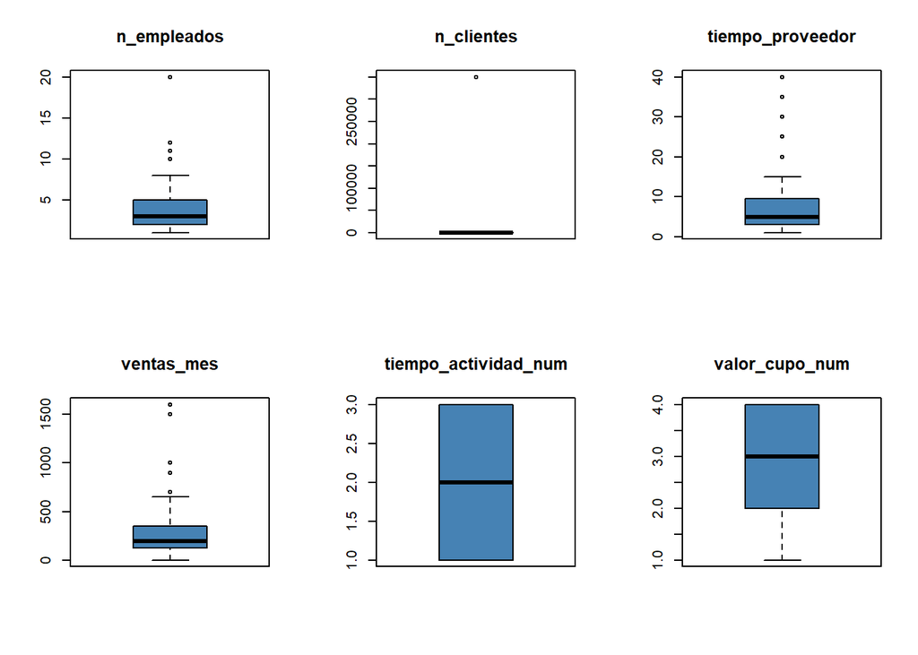

```r
#chunk2.3
# Boxplots para detectar outliers
par(mfrow = c(2, 3))
for (var in names(datos_completos)[1:6]) {
  boxplot(datos_completos[[var]], main = var, col = "steelblue")
}
```

```r
par(mfrow = c(1, 1))
```

```r
#chunk2.4

# TRATAMIENTO AVANZADO DE OUTLIERS
# ============================================

cat("TRATAMIENTO DE OUTLIERS\n")
```

```
## TRATAMIENTO DE OUTLIERS
```

```r
cat("========================================================\n\n")
# 1. IDENTIFICACIÓN DETALLADA
# ============================================

# Función para identificar outliers con diferentes umbrales
identificar_outliers_avanzado <- function(x, umbral_iqr = 1.5, metodo = "iqr") {
  if(metodo == "iqr") {
    q1 <- quantile(x, 0.25, na.rm = TRUE)
    q3 <- quantile(x, 0.75, na.rm = TRUE)
    iqr <- q3 - q1
    lower <- q1 - umbral_iqr * iqr
    upper <- q3 + umbral_iqr * iqr
    return(list(es_outlier = x < lower | x > upper,
                lower = lower, upper = upper))
  }
}

# Clasificar variables problemáticas
vars_problematicas <- c("n_clientes", "ventas_mes", "n_empleados",
                        "medida_almacen", "tiempo_proveedor")
vars_conteo_problematicas <- c("num_valores_dist", "num_cond_perm",
                               "num_tipos_publicidad", "num_lineas")
vars_ordinales_problematicas <- c("frec_compra_num")



# Mostrar situación inicial
for(var in c(vars_problematicas, vars_conteo_problematicas, vars_ordinales_problematicas)) {
  if(var %in% names(datos_completos)) {
    outliers_info <- identificar_outliers_avanzado(datos_completos[[var]], umbral_iqr = 1.5)
    n_out <- sum(outliers_info$es_outlier, na.rm = TRUE)
    pct_out <- round(n_out / length(datos_completos[[var]]) * 100, 1)

    if(n_out > 0) {
      cat(sprintf("  • %s: %d outliers (%.1f%%) - Rango [%.0f, %.0f]\n",
                  var, n_out, pct_out,
                  min(datos_completos[[var]], na.rm = TRUE),
                  max(datos_completos[[var]], na.rm = TRUE)))
    }
  }
}
```

```
##   • n_clientes: 4 outliers (4.0%) - Rango [40, 350000]
##   • ventas_mes: 6 outliers (6.1%) - Rango [0, 1600]
##   • n_empleados: 5 outliers (5.1%) - Rango [1, 20]
##   • tiempo_proveedor: 5 outliers (5.1%) - Rango [1, 40]
##   • num_valores_dist: 8 outliers (8.1%) - Rango [1, 7]
##   • num_cond_perm: 2 outliers (2.0%) - Rango [1, 4]
##   • frec_compra_num: 10 outliers (10.1%) - Rango [1, 3]
```

```r
# 2. TRATAMIENTO ESPECÍFICO POR VARIABLE
# ============================================

cat("\n\n APLICACION DE TRATAMIENTOS ESPECÍFICOS:\n")
```

```
##
##
##  APLICACION DE TRATAMIENTOS ESPECÍFICOS:
```

```r
cat("----------------------------------------\n")
datos_mejorados <- datos_completos

# 2.1 Para n_clientes (el outlier de 350,000 es extremo)
if("n_clientes" %in% names(datos_mejorados)) {
  # Winsorización más agresiva al 95%
  q95_clientes <- quantile(datos_mejorados$n_clientes, 0.95, na.rm = TRUE)
  q05_clientes <- quantile(datos_mejorados$n_clientes, 0.05, na.rm = TRUE)

  n_original <- sum(datos_mejorados$n_clientes > q95_clientes |
                    datos_mejorados$n_clientes < q05_clientes, na.rm = TRUE)

  datos_mejorados$n_clientes[datos_mejorados$n_clientes > q95_clientes] <- q95_clientes
  datos_mejorados$n_clientes[datos_mejorados$n_clientes < q05_clientes] <- q05_clientes

  cat(sprintf("  n_clientes: %d valores extremos → límite superior = %.0f\n",
              n_original, q95_clientes))
}
```

```
##   n_clientes: 10 valores extremos → límite superior = 305
```

```r
# 2.2 Para ventas_mes (transformación logarítmica)
if("ventas_mes" %in% names(datos_mejorados)) {
  # Verificar si hay ceros o negativos
  if(min(datos_mejorados$ventas_mes, na.rm = TRUE) > 0) {
    # Aplicar log
    ventas_log <- log(datos_mejorados$ventas_mes)

    # Detectar outliers en escala log
    outliers_log <- identificar_outliers_avanzado(ventas_log, umbral_iqr = 2.0)

    if(sum(outliers_log$es_outlier) > 0) {
      # Winsorizar en escala log
      q95_log <- quantile(ventas_log, 0.95, na.rm = TRUE)
      q05_log <- quantile(ventas_log, 0.05, na.rm = TRUE)

      ventas_log[ventas_log > q95_log] <- q95_log
      ventas_log[ventas_log < q05_log] <- q05_log

      # Transformar de vuelta
      datos_mejorados$ventas_mes <- exp(ventas_log)

      cat(sprintf("  ventas_mes: transformación logarítmica aplicada\n"))
    }
  }
}

# 2.3 Para n_empleados (winsorización al 90%)
if("n_empleados" %in% names(datos_mejorados)) {
  q90_emp <- quantile(datos_mejorados$n_empleados, 0.90, na.rm = TRUE)
  q10_emp <- quantile(datos_mejorados$n_empleados, 0.10, na.rm = TRUE)

  n_original <- sum(datos_mejorados$n_empleados > q90_emp |
                    datos_mejorados$n_empleados < q10_emp, na.rm = TRUE)

  datos_mejorados$n_empleados[datos_mejorados$n_empleados > q90_emp] <- q90_emp
  datos_mejorados$n_empleados[datos_mejorados$n_empleados < q10_emp] <- q10_emp

  cat(sprintf("  n_empleados: %d valores extremos → límite superior = %.0f\n",
              n_original, q90_emp))
}
```

```
##   n_empleados: 7 valores extremos → límite superior = 7
```

```r
# 2.4 Para variables de conteo (límite basado en percentil 95)
vars_conteo_tratar <- intersect(vars_conteo_problematicas, names(datos_mejorados))
for(var in vars_conteo_tratar) {
  q95 <- quantile(datos_mejorados[[var]], 0.95, na.rm = TRUE)
  n_original <- sum(datos_mejorados[[var]] > q95, na.rm = TRUE)

  if(n_original > 0) {
    datos_mejorados[[var]][datos_mejorados[[var]] > q95] <- q95
    cat(sprintf("  %s: %d valores > percentil 95 → limitados a %.0f\n",
                var, n_original, q95))
  }
}
```

```
##   num_cond_perm: 2 valores > percentil 95 → limitados a 3
##   num_tipos_publicidad: 1 valores > percentil 95 → limitados a 7
```

```r
# 2.5 Para frec_compra_num (variable ordinal, imputar por moda)
if("frec_compra_num" %in% names(datos_mejorados)) {
  # Identificar valores fuera de rango esperado (1-5)
  valores_validos <- datos_mejorados$frec_compra_num %in% 1:5
  if(any(!valores_validos, na.rm = TRUE)) {
    moda_frec <- as.numeric(names(sort(table(datos_mejorados$frec_compra_num[valores_validos]),
                                       decreasing = TRUE)[1]))
    n_original <- sum(!valores_validos, na.rm = TRUE)
    datos_mejorados$frec_compra_num[!valores_validos] <- moda_frec
    cat(sprintf("  frec_compra_num: %d valores atípicos → imputados por moda = %.0f\n",
                n_original, moda_frec))
  }
}

# 3. VERIFICACIÓN POST-TRATAMIENTO

cat("----------------------------------\n")
# Crear dataframes para comparación visual
df_comparacion <- data.frame()

for(var in c(vars_problematicas, vars_conteo_problematicas)) {
  if(var %in% names(datos_completos) & var %in% names(datos_mejorados)) {
    # Antes
    outliers_antes <- identificar_outliers_avanzado(datos_completos[[var]], umbral_iqr = 1.5)
    n_antes <- sum(outliers_antes$es_outlier, na.rm = TRUE)

    # Después
    outliers_despues <- identificar_outliers_avanzado(datos_mejorados[[var]], umbral_iqr = 1.5)
    n_despues <- sum(outliers_despues$es_outlier, na.rm = TRUE)

    df_comparacion <- rbind(df_comparacion, data.frame(
      Variable = var,
      Outliers_Antes = n_antes,
      Outliers_Despues = n_despues,
      Reduccion = paste0(round((1 - n_despues/n_antes) * 100, 1), "%")
    ))
  }
}

print(df_comparacion)
```

```
##               Variable Outliers_Antes Outliers_Despues Reduccion
## 1           n_clientes              4                0      100%
## 2           ventas_mes              6                6        0%
## 3          n_empleados              5                0      100%
## 4     tiempo_proveedor              5                5        0%
## 5     num_valores_dist              8                8        0%
## 6        num_cond_perm              2                0      100%
## 7 num_tipos_publicidad              0                0      NaN%
## 8           num_lineas              0                0      NaN%
```

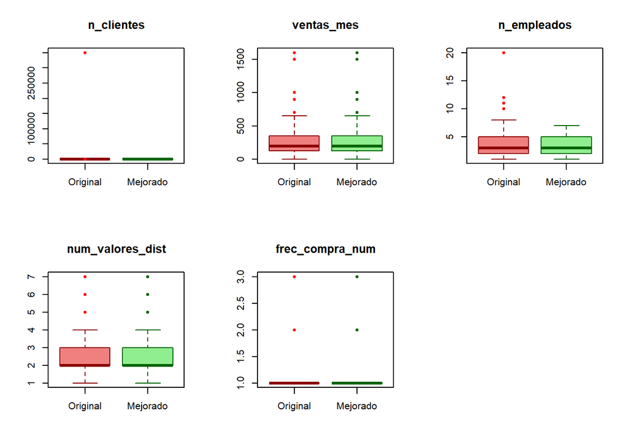

```r
# 4. VISUALIZACIÓN COMPARATIVA
# ==============================

par(mfrow = c(2, 3))
for(var in c("n_clientes", "ventas_mes", "n_empleados",
             "num_valores_dist", "frec_compra_num")) {
  if(var %in% names(datos_completos) & var %in% names(datos_mejorados)) {
    # Boxplot lado a lado
    boxplot(datos_completos[[var]], datos_mejorados[[var]],
            names = c("Original", "Mejorado"),
            main = var,
            col = c("lightcoral", "lightgreen"),
            border = c("darkred", "darkgreen"),
            outpch = 19,
            outcol = c("red", "darkgreen"))
  }
}
par(mfrow = c(1, 1))
```

```r
# 5. ACTUALIZAR DATASET PRINCIPAL
# =================================

datos_completos <- datos_mejorados
```

Matriz de correlaciones

```r
#chunk2.5
# MATRIZ DE CORRELACIÓN - SOLO VARIABLES NUMÉRICAS
# ============================================


# Crear directorio para checkpoints si no existe
if(!dir.exists("checkpoints")) {
  dir.create("checkpoints")
  cat("Directorio 'checkpoints' creado\n")
}

# Guardar dataset completo con toda la limpieza aplicada
saveRDS(datos_completos, "checkpoints/datos_limpios_checkpoint.rds")

# Guardar también en CSV para fácil inspección
write.csv(datos_completos, "checkpoints/datos_limpios_checkpoint.csv", row.names = FALSE)



cat("   Dimensiones:", nrow(datos_completos), "x", ncol(datos_completos), "\n")
```

```
##    Dimensiones: 99 x 29
```

```r
cat("   Variables principales:", paste(names(datos_completos)[1:5], collapse = ", "), "...\n\n")
```

```
##    Variables principales: n_empleados, n_clientes, tiempo_proveedor, ventas_mes, tiempo_actividad_num ...
```

```r
# SELECCIÓN DE VARIABLES NUMÉRICAS
# ============================================

# Seleccion de numéricas para la matriz de correlación
datos_numericos <- datos_completos %>% select(where(is.numeric))

cat("MATRIZ DE CORRELACIÓN\n")
```

```
## MATRIZ DE CORRELACIÓN
```

```r
cat("========================================================\n")
cat("Variables numéricas seleccionadas:", ncol(datos_numericos), "\n")
```

```
## Variables numéricas seleccionadas: 29
```

```r
cat("Observaciones:", nrow(datos_numericos), "\n\n")
```

```
## Observaciones: 99
```

```r
# Verificar que no hay NAs
if(any(is.na(datos_numericos))) {
  datos_numericos <- datos_numericos %>%
    mutate(across(everything(), ~ifelse(is.na(.), mean(., na.rm = TRUE), .)))
}

# CHECKPOINT 2: GUARDAR DATOS NUMÉRICOS
# ============================================

saveRDS(datos_numericos, "checkpoints/datos_numericos_checkpoint.rds")
write.csv(datos_numericos, "checkpoints/datos_numericos_checkpoint.csv", row.names = FALSE)

cat("   Dimensiones numéricas:", nrow(datos_numericos), "x", ncol(datos_numericos), "\n\n")
```

```
##    Dimensiones numéricas: 99 x 29
```

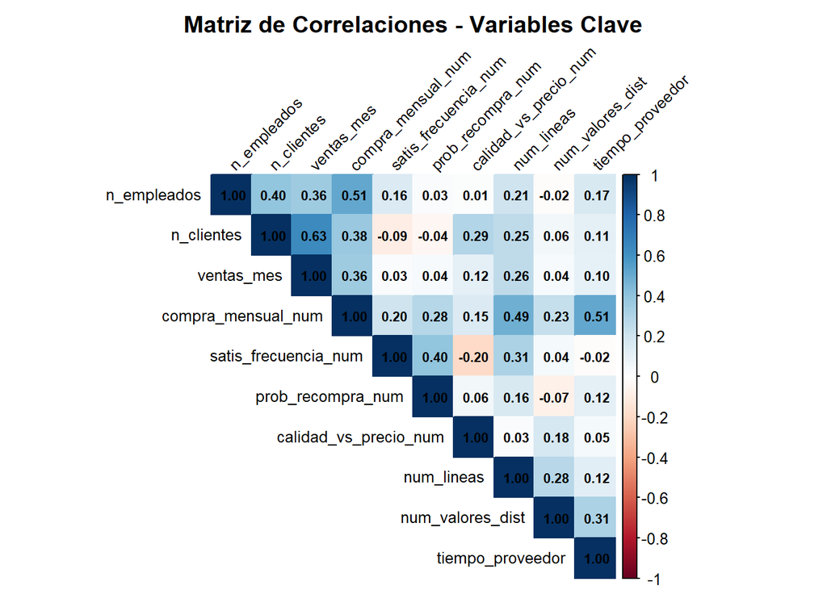

```r
# MATRIZ DE CORRELACIÓN
# ============================================

# Calcular matriz de correlación
cor_matrix <- cor(datos_numericos, use = "complete.obs")

# Visualizacion
# Identificar variables clave para el negocio
vars_clave <- c("n_empleados", "n_clientes", "ventas_mes", "compra_mensual_num",
                "satis_frecuencia_num", "prob_recompra_num", "calidad_vs_precio_num",
                "num_lineas", "num_valores_dist", "tiempo_proveedor")

# Filtro de variables clave presentes en el dataset numérico
vars_clave <- intersect(vars_clave, names(datos_numericos))

if(length(vars_clave) >= 3) {
  cor_matrix_filtrada <- cor(datos_numericos[, vars_clave], use = "complete.obs")

  # Visualizar
  corrplot(cor_matrix_filtrada,
           method = "color",
           type = "upper",
           tl.cex = 0.8,
           tl.col = "black",
           tl.srt = 45,
           addCoef.col = "black",
           number.cex = 0.7,
           title = "Matriz de Correlaciones - Variables Clave",
           mar = c(0, 0, 2, 0))
} else {
  # Si no hay suficientes variables clave, mostrar todas
  corrplot(cor_matrix,
           method = "color",
           type = "upper",
           tl.cex = 0.6,
           tl.col = "black",
           title = "Matriz de Correlaciones - Todas las Variables",
           mar = c(0, 0, 2, 0))
}
```

```r
# ANÁLISIS DE CORRELACIONES FUERTES
# ============================================

cat("\n\n  CORRELACIONES FUERTES (|r| > 0.5):\n")
```

```
##
##
##   CORRELACIONES FUERTES (|r| > 0.5):
```

```r
cat("----------------------------------------\n")
# Convertir matriz a data frame para análisis
cor_df <- as.data.frame(as.table(cor_matrix))
names(cor_df) <- c("Var1", "Var2", "Correlacion")
cor_df <- cor_df[cor_df$Var1 != cor_df$Var2, ]  # Eliminar diagonal
cor_df <- cor_df[!duplicated(t(apply(cor_df[,1:2], 1, sort))), ]  # Eliminar duplicados

# Filtrar correlaciones fuertes
cor_fuertes <- cor_df[abs(cor_df$Correlacion) > 0.5, ]
cor_fuertes <- cor_fuertes[order(-abs(cor_fuertes$Correlacion)), ]

if(nrow(cor_fuertes) > 0) {
  print(cor_fuertes)

  # Interpretación comercial
  cat("\n\n INTERPRETACIÓN COMERCIAL:\n")

  for(i in 1:min(5, nrow(cor_fuertes))) {
    v1 <- as.character(cor_fuertes$Var1[i])
    v2 <- as.character(cor_fuertes$Var2[i])
    r <- cor_fuertes$Correlacion[i]

    cat(sprintf("\n• %s ↔ %s (r = %.3f):\n", v1, v2, r))

    # Interpretaciones específicas según contexto
    if(grepl("n_empleados", v1) & grepl("ventas", v2) |
       grepl("n_empleados", v2) & grepl("ventas", v1)) {
      cat("  → A más empleados, mayores ventas (economías de escala)\n")
    }
    else if(grepl("n_clientes", v1) & grepl("ventas", v2) |
            grepl("n_clientes", v2) & grepl("ventas", v1)) {
      cat("  → Base de clientes amplia genera mayores ingresos\n")
    }
    else if(grepl("satis", v1) & grepl("prob_recompra", v2) |
            grepl("satis", v2) & grepl("prob_recompra", v1)) {
      cat("  → Clientes satisfechos tienen mayor probabilidad de recompra\n")
    }
    else if(grepl("num_lineas", v1) & grepl("n_empleados", v2) |
            grepl("num_lineas", v2) & grepl("n_empleados", v1)) {
      cat("  → Mayor diversificación requiere más personal\n")
    }
    else if(grepl("calidad", v1) & grepl("precio", v2) |
            grepl("calidad", v2) & grepl("precio", v1)) {
      if(r > 0) {
        cat("  → Quienes valoran calidad también valoran precio (clientes equilibrados)\n")
      } else {
        cat("  → Trade-off entre calidad y precio (clientes definen prioridad)\n")
      }
    }
    else {
      if(r > 0) {
        cat("  → Relación POSITIVA: las variables aumentan juntas\n")
      } else {
        cat("  → Relación NEGATIVA: cuando una aumenta, la otra disminuye\n")
      }
    }
  }
} else {
  cat("No se encontraron correlaciones fuertes (>0.5)\n")
}
```

```
##                     Var1                 Var2 Correlacion
## 152   compra_mensual_num       valor_cupo_num   0.6701765
## 122       valor_cupo_num tiempo_actividad_num   0.6540776
## 33            ventas_mes           n_clientes   0.6349280
## 123   compra_mensual_num tiempo_actividad_num   0.6179707
## 192  vehiculo_propio_num   compra_mensual_num   0.6138820
## 163  vehiculo_propio_num       valor_cupo_num   0.6083760
## 422  marca_memorable_num   prod_fidelidad_num   0.6023012
## 63  tiempo_actividad_num     tiempo_proveedor   0.5577611
## 6         valor_cupo_num          n_empleados   0.5454063
## 134  vehiculo_propio_num tiempo_actividad_num   0.5160247
## 65    compra_mensual_num     tiempo_proveedor   0.5142754
## 7     compra_mensual_num          n_empleados   0.5107326
##
##
##  INTERPRETACIÓN COMERCIAL:
##
## • compra_mensual_num ↔ valor_cupo_num (r = 0.670):
##   → Relación POSITIVA: las variables aumentan juntas
##
## • valor_cupo_num ↔ tiempo_actividad_num (r = 0.654):
##   → Relación POSITIVA: las variables aumentan juntas
##
## • ventas_mes ↔ n_clientes (r = 0.635):
##   → Base de clientes amplia genera mayores ingresos
##
## • compra_mensual_num ↔ tiempo_actividad_num (r = 0.618):
##   → Relación POSITIVA: las variables aumentan juntas
##
## • vehiculo_propio_num ↔ compra_mensual_num (r = 0.614):
##   → Relación POSITIVA: las variables aumentan juntas
```

```r
# GUARDAR MATRIZ DE CORRELACIÓN
# ============================================

write.csv(cor_matrix, "checkpoints/matriz_correlacion.csv")
cat("\n  Matriz de correlación guardada en 'checkpoints/matriz_correlacion.csv'\n")
```

```
##
##   Matriz de correlación guardada en 'checkpoints/matriz_correlacion.csv'
```

```r
# GUARDAR DATASET NUMÉRICO PARA PRÓXIMOS PASOS
# ============================================

# Actualizar dataset datos_completos
datos_completos_numericos <- datos_numericos

cat("\n\n Dataset numérico creado:", ncol(datos_completos_numericos), "variables\n")
```

```
##
##
##  Dataset numérico creado: 29 variables
```

En el output se pueden observar algunas correlaciones entre las variables que pueden aportar un importante analisis preliminar para el estudio.

*compra mensual-Valor cupo* al ser la correlacion mas alta es importante hacer un analisis, esta correlacion puede sirgnificar que entre mayor sea el cupo crediticio de los subdistribuidores, mas capacidad de compra pueden tener, por lo que es importante que los almacenes manejen creditos acordes a sus posibilidades

*Valor de cupo, compra mensual y vehiculo propio - tiempo de actividad* estas 3 variables hacen ver que entre mayor sea el tiempo en actividad de los subdistribuidores, mayores posibilidades y recursos pueden disponer ya que saben como se maneja el negocio y no se atienen tanto a la incertidumbre, saben como y cuanto invertir

*compra mensual y cupo de credito- vehiculo propio* aquellos que tienen vehiculo propio pueden tener un credito mas alto y comprar mas ya que tienen un plus en la capacidad operativa y logistica que permite aprovechar ciertos factores como los descuentos por grandes columenes por ejemplo.

*recordar marcas-Fidelidad* el analisis de correlacions dice que probablemente aquellos que recuerdan marcas tienden a serle fiel a alguna

*compra mensual- Años con proveedor* el analisis dice que es muy probable que aquellos subdistribuidores que tienen relacion larga con sus proveedores tieden a comprarles mas

# 3. ANALISIS DE COMPONENTES PRINCIPALES

```r
# chunk3.1 PCA con preprocesamiento
# ============================================

library(caret)

# 1. Separar variables por tipo
vars_continuas <- c("n_empleados", "n_clientes", "ventas_mes", "tiempo_proveedor")
vars_ordinales <- c("compra_mensual_num", "calidad_vs_precio_num", "frec_compra_num",
                    "satis_frecuencia_num", "prob_recompra_num")
vars_binarias <- c("almacenamiento_num", "tiene_alternativas_num", "tiene_presupuesto_num",
                   "prod_fidelidad_num", "marca_memorable_num", "vehiculo_propio_num",
                   "recomendaria_num", "asistencia_tecnica_num")

# 2. Preprocesamiento diferenciado
datos_prep <- datos_numericos

# Escalar continuas
datos_prep[vars_continuas] <- scale(datos_prep[vars_continuas])


# 3. Aplicar PCA
vars_pca <- c(vars_continuas, vars_ordinales)
vars_pca <- vars_pca[vars_pca %in% names(datos_prep)]

pca_result <- PCA(datos_prep[vars_pca],
                  scale.unit = TRUE,
                  graph = FALSE,
                  ncp = min(10, length(vars_pca)))
#pca_result <- PCA(datos_prep[vars_pca],
 #                 scale.unit = FALSE,
  #                graph = FALSE,
   #               ncp = min(10, length(vars_pca)))

# 4. Usar componentes que explican al menos 80% de varianza
var_acum <- cumsum(pca_result$eig[,2])
ncomp_optimo <- which(var_acum >= 80)[1]
if(is.na(ncomp_optimo)) ncomp_optimo <- ncol(pca_result$ind$coord)

pca_result <- PCA(datos_prep[vars_pca],
                  scale.unit = FALSE,
                  graph = FALSE,
                  ncp = ncomp_optimo)

cat("Componentes seleccionados:", ncomp_optimo , "\n")
```

```
## Componentes seleccionados: 5
```

```r
cat("Varianza acumulada:", round(var_acum[ncomp_optimo], 1), "%\n")
```

```
## Varianza acumulada: 82.1 %
```

```r
tabla_variables_pca <- data.frame(
  variable = names(datos_pca)
)

tabla_variables_pca <- tabla_variables_pca %>% arrange(variable)
print(tabla_variables_pca)
```

```
##                   variable
## 1       almacenamiento_num
## 2   asistencia_tecnica_num
## 3    calidad_vs_precio_num
## 4       compra_mensual_num
## 5  encuentra_productos_num
## 6        facil_credito_num
## 7          frec_compra_num
## 8       frec_urgencias_num
## 9      infl_descuentos_num
## 10     marca_memorable_num
## 11              n_clientes
## 12             n_empleados
## 13           num_cond_perm
## 14              num_lineas
## 15    num_tipos_publicidad
## 16        num_valores_dist
## 17       prob_recompra_num
## 18      prod_fidelidad_num
## 19        recomendaria_num
## 20    satis_frecuencia_num
## 21    tiempo_actividad_num
## 22       tiempo_espera_num
## 23        tiempo_proveedor
## 24  tiene_alternativas_num
## 25   tiene_presupuesto_num
## 26    tipo_punto_venta_num
## 27          valor_cupo_num
## 28     vehiculo_propio_num
## 29              ventas_mes
```

```r
cat("\nTotal en datos_pca:", nrow(tabla_variables_pca), "\n")
```

```
##
## Total en datos_pca: 29
```

```r
# Grafico de barras de varianza explicada con etiquetas de porcentaje
# + análisis cuantitativo complementario
# ============================================

varianza_explicada <- pca_result$eig[,2]
varianza_acumulada  <- cumsum(varianza_explicada)
eigenvalues          <- pca_result$eig[,1]
componentes           <- 1:length(varianza_explicada)

df_varianza <- data.frame(
  Componente          = componentes,
  Eigenvalue          = round(eigenvalues, 3),
  Varianza_Explicada  = round(varianza_explicada, 2),
  Varianza_Acumulada  = round(varianza_acumulada, 2)
)

# 1. TABLA CUANTITATIVA (Eigenvalues + criterio de Kaiser)
cat("TABLA DE VARIANZA POR COMPONENTE\n")
```

```
## TABLA DE VARIANZA POR COMPONENTE
```

```r
print(df_varianza)
```

```
##        Componente Eigenvalue Varianza_Explicada Varianza_Acumulada
## comp 1          1      2.788              31.87              31.87
## comp 2          2      2.122              24.25              56.12
## comp 3          3      1.162              13.28              69.40
## comp 4          4      0.857               9.79              79.19
## comp 5          5      0.653               7.47              86.66
## comp 6          6      0.402               4.59              91.25
## comp 7          7      0.325               3.72              94.97
## comp 8          8      0.279               3.19              98.16
## comp 9          9      0.161               1.84             100.00
```

```r
n_kaiser <- sum(eigenvalues > 1)
n_80pct  <- which(varianza_acumulada >= 80)[1]

cat("\nCriterio de Kaiser (eigenvalue > 1): retiene", n_kaiser, "componente(s)\n")
```

```
##
## Criterio de Kaiser (eigenvalue > 1): retiene 3 componente(s)
```

```r
cat("Criterio de varianza acumulada (>= 80%): retiene", n_80pct, "componente(s)\n")
```

```
## Criterio de varianza acumulada (>= 80%): retiene 5 componente(s)
```

```r
cat("Varianza explicada por los primeros", n_kaiser, "componente(s):",
    round(varianza_acumulada[n_kaiser], 1), "%\n")
```

```
## Varianza explicada por los primeros 3 componente(s): 69.4 %
```

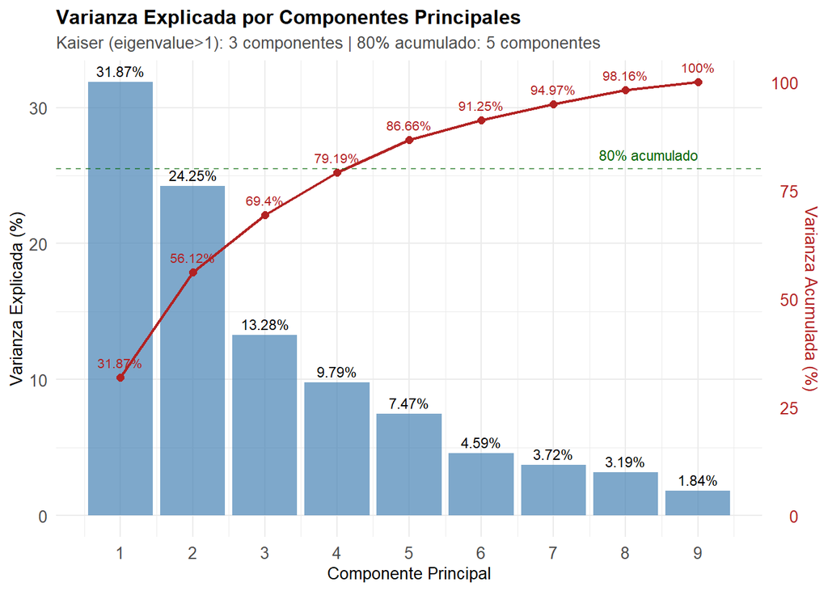

```r
# 2. GRÁFICO: barras (varianza individual) + línea (varianza acumulada)
escala_secundaria <- max(varianza_explicada) / 100  # para alinear el eje secundario con %

ggplot(df_varianza, aes(x = Componente)) +
  geom_bar(aes(y = Varianza_Explicada), stat = "identity",
           fill = "steelblue", alpha = 0.7) +
  geom_text(aes(y = Varianza_Explicada,
                label = paste0(Varianza_Explicada, "%")),
            vjust = -0.5, size = 3) +
  geom_line(aes(y = Varianza_Acumulada * escala_secundaria),
            color = "firebrick", linewidth = 0.8, group = 1) +
  geom_point(aes(y = Varianza_Acumulada * escala_secundaria),
             color = "firebrick", size = 2) +
  geom_text(aes(y = Varianza_Acumulada * escala_secundaria,
                label = paste0(Varianza_Acumulada, "%")),
            vjust = -1, size = 2.8, color = "firebrick") +
  geom_hline(yintercept = 80 * escala_secundaria,
             linetype = "dashed", color = "darkgreen", alpha = 0.6) +
  annotate("text", x = max(componentes), y = 80 * escala_secundaria,
           label = "80% acumulado", vjust = -0.8, hjust = 1,
           size = 3, color = "darkgreen") +
  scale_y_continuous(
    name = "Varianza Explicada (%)",
    sec.axis = sec_axis(~ . / escala_secundaria, name = "Varianza Acumulada (%)")
  ) +
  scale_x_continuous(breaks = componentes) +
  labs(title = "Varianza Explicada por Componentes Principales",
       subtitle = paste0("Kaiser (eigenvalue>1): ", n_kaiser,
                          " componentes | 80% acumulado: ", "5", " componentes"),
       x = "Componente Principal") +
  theme_minimal() +
  theme(
    plot.title = element_text(size = 12, face = "bold", margin = margin(b = 5)),
    plot.subtitle = element_text(size = 10, color = "grey30"),
    axis.text.x = element_text(size = 10),
    axis.text.y = element_text(size = 10),
    axis.title.x = element_text(size = 10),
    axis.title.y = element_text(size = 10),
    axis.title.y.right = element_text(color = "firebrick"),
    axis.text.y.right = element_text(color = "firebrick")
  )
```

```r
# 3. RESUMEN FINAL
cat("Componentes seleccionados (criterio Kaiser):", n_kaiser, "\n")
```

```
## Componentes seleccionados (criterio Kaiser): 3
```

```r
# chunk3.2
#Tabla de varianza
# ============================================

# Tabla de varianza
varianza_df <- data.frame(
  Componente = 1:nrow(pca_result$eig),
  Eigenvalue = round(pca_result$eig[,1], 3),
  Varianza_Individual = round(pca_result$eig[,2], 2),
  Varianza_Acumulada = round(pca_result$eig[,3], 2)
)

print(varianza_df)
```

```
##        Componente Eigenvalue Varianza_Individual Varianza_Acumulada
## comp 1          1      2.788               31.87              31.87
## comp 2          2      2.122               24.25              56.12
## comp 3          3      1.162               13.28              69.40
## comp 4          4      0.857                9.79              79.19
## comp 5          5      0.653                7.47              86.66
## comp 6          6      0.402                4.59              91.25
## comp 7          7      0.325                3.72              94.97
## comp 8          8      0.279                3.19              98.16
## comp 9          9      0.161                1.84             100.00
```

```r
# Selección: componentes con eigenvalue > 1
n_componentes_usar <- sum(pca_result$eig[,1] > 1)

# Si da menos de 2, tomar los que explican al menos 80%
if(n_componentes_usar < 2) {
  var_acum <- cumsum(pca_result$eig[,2])
  n_componentes_usar <- which(var_acum >= 80)[1]
  if(is.na(n_componentes_usar)) n_componentes_usar <- 3
}

cat("\nComponentes seleccionados:", n_componentes_usar)
```

```
##
## Componentes seleccionados: 3
```

```r
cat("\nVarianza explicada:", round(varianza_df$Varianza_Acumulada[n_componentes_usar], 1), "%\n")
```

```
##
## Varianza explicada: 69.4 %
```

```r
# Guardar para chunks siguientes
saveRDS(n_componentes_usar, "checkpoints/n_componentes_usar.rds")
```

```r
#
# ============================================
# chunk3.2b - Estructura subyacente: contribución y correlación de variables
# ============================================
contrib_df <- as.data.frame(round(pca_result$var$contrib[, 1:3], 2))
contrib_df$Variable <- rownames(contrib_df)
contrib_df <- contrib_df %>% select(Variable, everything())
cat("CONTRIBUCIÓN DE VARIABLES A CADA COMPONENTE (%)\n")
```

```
## CONTRIBUCIÓN DE VARIABLES A CADA COMPONENTE (%)
```

```r
print(contrib_df)
```

```
##                                    Variable Dim.1 Dim.2 Dim.3
## n_empleados                     n_empleados 17.34  0.12  1.10
## n_clientes                       n_clientes 13.77 10.72 14.80
## ventas_mes                       ventas_mes 14.00  4.59 18.77
## tiempo_proveedor           tiempo_proveedor  7.85  0.79 46.48
## compra_mensual_num       compra_mensual_num 34.92  0.09 13.19
## calidad_vs_precio_num calidad_vs_precio_num  0.95  8.17  0.12
## frec_compra_num             frec_compra_num  0.52  1.81  0.40
## satis_frecuencia_num   satis_frecuencia_num  9.42 70.94  4.64
## prob_recompra_num         prob_recompra_num  1.21  2.76  0.51
```

```r
coord_df <- as.data.frame(round(pca_result$var$coord[, 1:3], 2))
coord_df$Variable <- rownames(coord_df)
coord_df <- coord_df %>% select(Variable, everything())
cat("\nCOORDENADAS (DIRECCIÓN Y FUERZA DE LA CORRELACIÓN)\n")
```

```
##
## COORDENADAS (DIRECCIÓN Y FUERZA DE LA CORRELACIÓN)
```

```r
print(coord_df)
```

```
##                                    Variable Dim.1 Dim.2 Dim.3
## n_empleados                     n_empleados  0.70  0.05  0.11
## n_clientes                       n_clientes  0.62  0.48  0.41
## ventas_mes                       ventas_mes  0.62  0.31  0.47
## tiempo_proveedor           tiempo_proveedor  0.47  0.13 -0.73
## compra_mensual_num       compra_mensual_num  0.99  0.04 -0.39
## calidad_vs_precio_num calidad_vs_precio_num  0.16  0.42  0.04
## frec_compra_num             frec_compra_num -0.12  0.20  0.07
## satis_frecuencia_num   satis_frecuencia_num  0.51 -1.23  0.23
## prob_recompra_num         prob_recompra_num  0.18 -0.24 -0.08
```

```r
promedio_esperado <- 100 / nrow(contrib_df)
cat("\nContribución promedio esperada por variable:", round(promedio_esperado, 2), "%\n\n")
```

```
##
## Contribución promedio esperada por variable: 11.11 %
```

```r
for (dim in 1:3) {
  cat("---- Dimensión", dim, "----\n")
  col_dim <- paste0("Dim.", dim)
  vars_dominantes <- contrib_df %>%
    select(Variable, all_of(col_dim)) %>%
    filter(.data[[col_dim]] > promedio_esperado) %>%
    arrange(desc(.data[[col_dim]]))
  print(vars_dominantes)
  cat("\n")
}
```

```
## ---- Dimensión 1 ----
##                              Variable Dim.1
## compra_mensual_num compra_mensual_num 34.92
## n_empleados               n_empleados 17.34
## ventas_mes                 ventas_mes 14.00
## n_clientes                 n_clientes 13.77
##
## ---- Dimensión 2 ----
##                                  Variable Dim.2
## satis_frecuencia_num satis_frecuencia_num 70.94
##
## ---- Dimensión 3 ----
##                              Variable Dim.3
## tiempo_proveedor     tiempo_proveedor 46.48
## ventas_mes                 ventas_mes 18.77
## n_clientes                 n_clientes 14.80
## compra_mensual_num compra_mensual_num 13.19
```

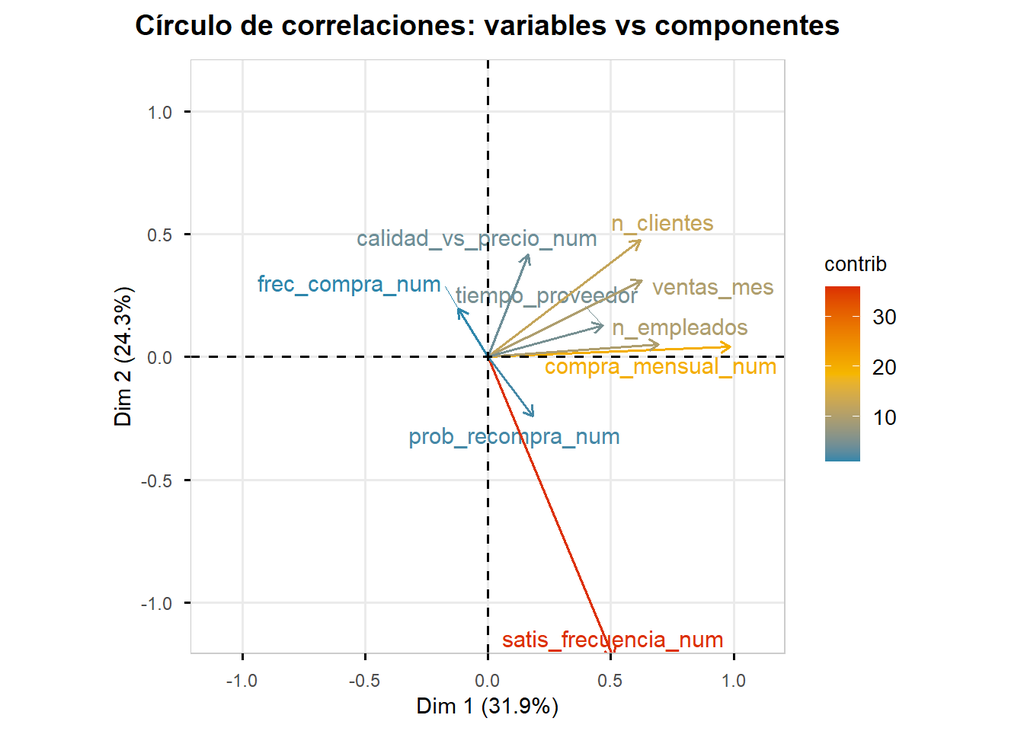

```r
# Seleccionar solo las variables con mayor contribución a Dim1-Dim2 (evita saturación visual)
p_circulo <- fviz_pca_var(pca_result,
             col.var = "contrib",
             gradient.cols = c("#2E86AB", "#F5B700", "#DC2F02"),
             repel = TRUE,
             select.var = list(contrib = 10),   # solo las 10 variables más relevantes
             labelsize = 4,
             arrowsize = 0.6,
             ggtheme = theme_minimal(base_size = 13),
             title = "Círculo de correlaciones: variables vs componentes") +
  labs(x = paste0("Dim 1 (", round(pca_result$eig[1, 2], 1), "%)"),
       y = paste0("Dim 2 (", round(pca_result$eig[2, 2], 1), "%)")) +
  theme(
    plot.title = element_text(size = 14, face = "bold", hjust = 0.5, margin = margin(b = 10)),
    legend.position = "right",
    legend.title = element_text(size = 10),
    axis.title = element_text(size = 11),
    axis.text = element_text(size = 9),
    panel.grid.minor = element_blank(),
    panel.border = element_rect(color = "grey80", fill = NA, linewidth = 0.5)
  ) +
  coord_equal(xlim = c(-1.1, 1.1), ylim = c(-1.1, 1.1))

print(p_circulo)
```